# Screening, projection and dense kernels for ultra-high-dimensional genomic prediction: a replication, benchmark and calibration study of TARP on *Arabidopsis thaliana*

# 2. Setup and helper functions

```r
suppressPackageStartupMessages({ library(bigsnpr); library(bigstatsr); library(parallel) })
if (!requireNamespace("RhpcBLASctl", quietly = TRUE)) {
  stop("Run once in a terminal: micromamba install -c conda-forge r-rhpcblasctl")
}
# bigstatsr refuses nested parallelism, so BLAS is pinned to one thread and parallelism comes from ncores
RhpcBLASctl::blas_set_num_threads(1)
dir.create("cache", showWarnings = FALSE)
```

```r
## ---------- generic infrastructure ----------
# Run fun(seed) for every seed, checkpointing each seed (resumable); reuse a final cache or a legacy checkpoint.
run_seeds <- function(name, fun, seeds = seq_len(N_REPS), legacy = NULL) {
  final <- file.path("cache", paste0(name, ".rds"))
  if (USE_CACHE && file.exists(final)) return(readRDS(final))
  if (USE_CACHE && !is.null(legacy) && file.exists(legacy)) {
    x <- readRDS(legacy); return(if (is.data.frame(x)) x else do.call(rbind, x))
  }
  part <- file.path("cache", paste0(name, "_partial.rds"))
  res <- if (file.exists(part)) readRDS(part) else list()
  for (s in seeds) {
    if (length(res) >= s && !is.null(res[[s]])) next
    t0 <- Sys.time(); res[[s]] <- fun(s); saveRDS(res, part)
    cat(sprintf("[%s] seed %d done in %.1f min\n", name, s, as.numeric(difftime(Sys.time(), t0, units = "mins"))))
  }
  out <- do.call(rbind, res); saveRDS(out, final); out
}
make_split <- function(seed_i, pool = seq_len(n)) {      # same RNG path as every experiment
  set.seed(seed_i)
  tr <- sample(pool, size = round(0.8 * length(pool)))
  list(tr = tr, te = setdiff(pool, tr))
}
sem <- function(x) sd(x) / sqrt(length(x))

## ---------- TARP building blocks ----------
# Step 1: randomized independence screening using ONLY the given training rows.
screen_set <- function(tr_rows, y_vec) {
  gw <- big_univLinReg(G2, y.train = y_vec, ind.train = tr_rows, ncores = N_CORES)
  tt <- gw$estim / gw$std.err
  r <- sign(tt) * sqrt(tt^2 / (tt^2 + (length(tr_rows) - 2))); r[is.na(r)] <- 0   # marginal correlation
  delta <- max(0, (1 + log(p / length(tr_rows))) / 2)
  q_in <- abs(r)^delta; q_in <- q_in / max(q_in)                                  # inclusion probabilities
  list(inc = which(rbinom(p, 1, q_in) == 1), r = r)
}
std_cols <- function(Xs, tr_rows, other_rows) {          # standardize with training statistics only
  cm <- colMeans(Xs[tr_rows, ]); cs <- apply(Xs[tr_rows, ], 2, sd); cs[cs == 0] <- 1
  list(tr = scale(Xs[tr_rows, ], center = cm, scale = cs), other = scale(Xs[other_rows, ], center = cm, scale = cs))
}
screened_gram <- function(inc) {                          # n x n kernel of the screened SNPs over all rows
  Xs <- G2[, inc]; cs <- apply(Xs, 2, sd); keep <- cs > 0
  Xs <- scale(Xs[, keep, drop = FALSE], center = TRUE, scale = cs[keep])
  tcrossprod(Xs) / sum(keep)
}
# Step 2: sparse ternary random matrix, entries +-1/sqrt(2 psi) with probability psi each
tarp_omega <- function(p_gamma, l, psi = 0.25) {
  u <- runif(p_gamma * l); Om <- matrix(0, p_gamma, l); val <- 1 / sqrt(2 * psi)
  Om[u < psi] <- val; Om[u >= psi & u < 2 * psi] <- -val; Om
}
# Step 3: closed-form NIG fit on the compressed features; returns test MSPE
nig_mspe <- function(Z_tr, Z_te, y_c, y_mean, y_te) {
  m <- ncol(Z_tr); mu <- solve(diag(m) + crossprod(Z_tr), crossprod(Z_tr, y_c))
  mean((y_te - ((Z_te %*% mu) + y_mean))^2)
}
# Paper's aggregation: B projections with m_n ~ U[2 log p, 3n/4], simple average of predictions
agg_tarp_pred <- function(X_tr, X_te, y_c, y_mean, p_total, B = 100) {
  p_g <- ncol(X_tr); n_tr <- nrow(X_tr); m_rng <- c(2 * log(p_total), 3 * n_tr / 4)
  rowMeans(vapply(seq_len(B), function(b) {
    m_b <- round(runif(1, m_rng[1], m_rng[2])); Om <- tarp_omega(p_g, m_b)
    Z_tr <- X_tr %*% Om; Z_te <- X_te %*% Om
    mu <- solve(diag(m_b) + crossprod(Z_tr), crossprod(Z_tr, y_c))
    as.numeric((Z_te %*% mu) + y_mean)
  }, numeric(nrow(X_te))))
}
# Randomized SVD (Halko-Martinsson-Tropp) with TARP's sparse matrix as the sketch and q power iterations
rsvd_basis <- function(X, k, q, l = k + 10, psi = 0.25) {
  Q <- qr.Q(qr(X %*% tarp_omega(ncol(X), l, psi)))
  for (i in seq_len(q)) { W <- qr.Q(qr(crossprod(X, Q))); Q <- qr.Q(qr(X %*% W)) }
  B <- crossprod(Q, X); e <- eigen(tcrossprod(B), symmetric = TRUE)
  sweep(crossprod(B, e$vectors[, 1:k, drop = FALSE]), 2, sqrt(pmax(e$values[1:k], 1e-12)), "/")
}
gram_pca_basis <- function(X, k) {                        # exact PCA directions via the n x n Gram matrix
  e <- eigen(tcrossprod(X), symmetric = TRUE)
  sweep(crossprod(X, e$vectors[, 1:k, drop = FALSE]), 2, sqrt(e$values[1:k]), "/")
}
energy <- function(X, V) sum((X %*% V)^2)

## ---------- kernel ridge / GBLUP building blocks ----------
log_evidence <- function(e_scaled, ytil2, rest_ss, n_, a = 0.01, b = 0.01) {   # closed-form NIG marginal likelihood
  s <- 1 + e_scaled; q <- sum(ytil2 / s) + rest_ss
  -0.5 * sum(log(s)) + a * log(b) - lgamma(a) + lgamma(a + n_ / 2) - (a + n_ / 2) * log(b + 0.5 * q)
}
# one eigendecomposition gives LOOCV, evidence and test error for every lambda
kernel_all <- function(K, K_new, y_c, y_new_c, lam_grid) {
  n_ <- length(y_c)
  eg <- eigen(K, symmetric = TRUE); e <- pmax(eg$values, 0); U <- eg$vectors
  yt <- as.numeric(crossprod(U, y_c))
  S <- outer(e, lam_grid, function(ei, li) ei / (ei + li))
  h <- (U^2) %*% S; yhat <- U %*% (S * yt)
  loo <- colMeans(((y_c - yhat) / pmax(1 - h, 1e-8))^2)
  ev <- vapply(lam_grid, function(l) log_evidence(e / l, yt^2, 0, n_), numeric(1))
  P <- K_new %*% (U %*% (yt / outer(e, lam_grid, "+")))
  list(loo = loo, ev = ev, test = colMeans((y_new_c - P)^2), pred = P)
}
kernel_curve <- function(K, K_new, y_c, lam_grid) {       # predictions of the centered response for every lambda
  eg <- eigen(K, symmetric = TRUE); e <- pmax(eg$values, 0); U <- eg$vectors
  yt <- as.numeric(crossprod(U, y_c))
  K_new %*% (U %*% (yt / outer(e, lam_grid, "+")))
}
mse_curve <- function(pred_c, y_new_c) colMeans((y_new_c - pred_c)^2)
gblup_fit <- function(tr, te, y_tr, lam_grid = LAM_GRID) {  # GBLUP with LOOCV lambda (valid: no supervised screening)
  ym <- mean(y_tr); kk <- kernel_all(Kfull[tr, tr], Kfull[te, tr], y_tr - ym, rep(0, length(te)), lam_grid)
  il <- which.min(kk$loo); list(pred = kk$pred[, il] + ym, lam = lam_grid[il])
}
gdist <- function(rows, cols) outer(dK[rows], dK[cols], "+") - 2 * Kfull[rows, cols]   # squared genomic distance
```

# 3. Data description

## 3.1. Removing duplicates and imputation

```r
if (!file.exists("arabidopsis_1135_matched.rds")) snp_readBed("arabidopsis_1135_matched.bed")
obj.bigSNP <- snp_attach("arabidopsis_1135_matched.rds")
G <- obj.bigSNP$genotypes; map <- obj.bigSNP$map; fam <- obj.bigSNP$fam
if (!file.exists("flowering_time.csv")) {
  download.file("https://arapheno.1001genomes.org/rest/study/12/values.csv", "flowering_time.csv", mode = "wb")
}

pheno <- read.csv("flowering_time.csv", stringsAsFactors = FALSE)

# Average replicate measurements within each accession.
mean_available <- function(z) {
  if (all(is.na(z))) NA_real_ else mean(z, na.rm = TRUE)
}

pheno_by_accession <- do.call(
  rbind,
  lapply(
    split(pheno, as.character(pheno$accession_id)),
    function(d) {
      data.frame(
        accession_id = as.character(d$accession_id[1]),
        FT10 = mean_available(d$FT10),
        FT16 = mean_available(d$FT16)
      )
    }
  )
)

rownames(pheno_by_accession) <- NULL

# Match accession-level means to genotype sample order.
y_all <- pheno_by_accession$FT10[
  match(as.character(fam$sample.ID),
        pheno_by_accession$accession_id)
]

y16 <- pheno_by_accession$FT16[
  match(as.character(fam$sample.ID),
        pheno_by_accession$accession_id)
]

# Verify phenotype matching.
stopifnot(!anyDuplicated(pheno_by_accession$accession_id))
stopifnot(sum(is.na(y_all)) == 0)

cat("Duplicate accession IDs after aggregation:",
    sum(duplicated(pheno_by_accession$accession_id)), "\n")
```

```
## Duplicate accession IDs after aggregation: 0
```

```r
n <- nrow(G); p <- ncol(G)
stopifnot(sum(is.na(y_all)) == 0)
G2 <- snp_fastImputeSimple(G, method = "mean2", ncores = N_CORES)   # mean-imputed copy used for modeling
cat("accessions n =", n, "| SNPs p =", format(p, big.mark = ","), "| p/n =", round(p / n), "\n")
```

```
## accessions n = 1003 | SNPs p = 1,712,884 | p/n = 1708
```

```r
pheno_by_accession[
  pheno_by_accession$accession_id == "8424",
]
```

```
##     accession_id  FT10  FT16
## 559         8424 68.25 77.75
```

### Missing Data Treatment

Variants (SNPs) with more than 10% missing genotype calls were removed using the PLINK `--geno 0.1` filter. Missing values among the remaining data were handled as follows.

Summary of missing-data treatment

| Data | Missing-value treatment | Data type |
| --- | --- | --- |
| Genotype calls | Mean imputation | Categorical (genotypes coded as 0/2) |
| FT10 (flowering time at 10°C) | Mean of available replicate measurements; no imputation | Numeric (continuous) |
| FT16 (flowering time at 16°C) | Mean of available replicate measurements; no imputation | Numeric (continuous) |

```r
cnt <- big_counts(G)

# Confirm that the four rows represent genotype states 0, 1, 2 and missing.
stopifnot(nrow(cnt) == 4L)

# Remove inherited row names to prevent the data.frame error.
tot <- as.numeric(rowSums(cnt))

geno_tab <- data.frame(
  State = c("0 (reference allele)",
            "1 (heterozygous)",
            "2 (alternate allele)",
            "missing"),
  Calls = tot,
  Share = tot / sum(tot),
  row.names = NULL
)

knitr::kable(
  geno_tab,
  digits = 4,
  row.names = FALSE,
  format.args = list(big.mark = ","),
  caption = "Genotype calls across all accessions and SNPs"
)
```

Genotype calls across all accessions and SNPs

| State | Calls | Share |
| --- | --- | --- |
| 0 (reference allele) | 1,412,842,958 | 0.8224 |
| 1 (heterozygous) | 0 | 0.0000 |
| 2 (alternate allele) | 219,804,345 | 0.1279 |
| missing | 85,375,349 | 0.0497 |

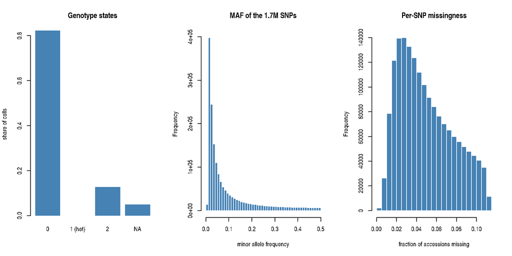

```r
# Calculate alternative-allele frequency correctly,
# accounting for genotype dosages 0, 1 and 2.
n_called <- colSums(cnt[1:3, , drop = FALSE])

f_alt <- rep(NA_real_, length(n_called))
valid <- n_called > 0

f_alt[valid] <- (
  cnt[2, valid] + 2 * cnt[3, valid]
) / (2 * n_called[valid])

maf <- pmin(f_alt, 1 - f_alt)
miss <- cnt[4, ] / n

par(mfrow = c(1, 3))

barplot(
  tot / sum(tot),
  names.arg = c("0", "1 (het)", "2", "NA"),
  col = "steelblue",
  border = NA,
  ylab = "share of calls",
  main = "Genotype states"
)

hist(
  maf,
  breaks = 40,
  col = "steelblue",
  border = "white",
  xlab = "minor allele frequency",
  main = "MAF of the 1.7M SNPs"
)

hist(
  miss,
  breaks = 40,
  col = "steelblue",
  border = "white",
  xlab = "fraction of accessions missing",
  main = "Per-SNP missingness"
)
```

```r
par(mfrow = c(1, 1))
```

```r
# Ensure both traits are numeric and select complete pairs
ft_data <- data.frame(
  FT10 = as.numeric(y_all),
  FT16 = as.numeric(y16)
)

ft_data <- ft_data[
  is.finite(ft_data$FT10) &
  is.finite(ft_data$FT16),
]

# Check the paired observations
cat("Number of complete FT10-FT16 pairs:", nrow(ft_data), "\n")
```

```
## Number of complete FT10-FT16 pairs: 970
```

```r
cat("FT10 range:", range(ft_data$FT10), "\n")
```

```
## FT10 range: 51.25 149.25
```

```r
cat("FT16 range:", range(ft_data$FT16), "\n")
```

```
## FT16 range: 32 145
```

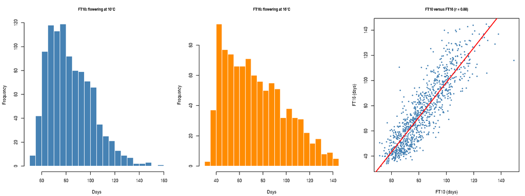

```r
r_ft <- cor(ft_data$FT10, ft_data$FT16)

# Three-panel figure
old_par <- par(no.readonly = TRUE)

par(
  mfrow = c(1, 3),
  mar = c(4.2, 4.2, 3.2, 1),
  cex.main = 0.9
)

# FT10 distribution
hist(
  y_all,
  breaks = 30,
  col = "steelblue",
  border = "white",
  xlab = "Days",
  main = "FT10: flowering at 10°C"
)

# FT16 distribution
hist(
  y16[is.finite(y16)],
  breaks = 30,
  col = "darkorange",
  border = "white",
  xlab = "Days",
  main = "FT16: flowering at 16°C"
)

# Paired scatterplot
plot(
  ft_data$FT10,
  ft_data$FT16,
  pch = 16,
  col = "steelblue",
  cex = 0.65,
  xlab = "FT10 (days)",
  ylab = "FT16 (days)",
  main = sprintf(
    "FT10 versus FT16 (r = %.2f)",
    r_ft
  )
)

# Add fitted regression line
abline(
  lm(FT16 ~ FT10, data = ft_data),
  col = "red",
  lwd = 2
)
```

```r
par(old_par)
```

FT16 is the same panel measured at a second temperature, so it is strongly correlated with FT10

## 3.2 Genome-wide relationship matrix and population structure

GBLUP, the dense baseline used below, needs the n x n genomic relationship matrix over **all** SNPs. It is built in one blockwise pass (20,000 SNPs per block; each block standardized with all accessions, no response involved) and cached; this one-time pass takes on the order of 20 minutes and is reused for every trait and split.

```r
gram_file <- "gram_full_snp.rds"
if (!file.exists(gram_file)) {
  RhpcBLASctl::blas_set_num_threads(N_CORES)                 # no bigstatsr parallel call inside this loop
  Kfull <- matrix(0, n, n); p_used <- 0
  blocks <- split(seq_len(p), ceiling(seq_len(p) / 20000)); t0 <- Sys.time()
  for (b in seq_along(blocks)) {
    Xb <- G2[, blocks[[b]]]; cm <- colMeans(Xb); cs <- apply(Xb, 2, sd); keep <- cs > 0
    Xb <- scale(Xb[, keep, drop = FALSE], center = cm[keep], scale = cs[keep])
    Kfull <- Kfull + tcrossprod(Xb); p_used <- p_used + sum(keep); rm(Xb)
    if (b %% 10 == 0) cat(sprintf("Gram block %d / %d (%.1f min)\n", b, length(blocks), as.numeric(difftime(Sys.time(), t0, units = "mins"))))
  }
  RhpcBLASctl::blas_set_num_threads(1)
  saveRDS(list(K = Kfull / p_used, p_used = p_used), gram_file); rm(Kfull)
}
gr <- readRDS(gram_file); Kfull <- gr$K; dK <- diag(Kfull)
cat("Gram matrix", dim(Kfull), "built from", format(gr$p_used, big.mark = ","), "non-constant SNPs; mean diagonal", round(mean(dK), 3), "\n")
```

```
## Gram matrix 1003 1003 built from 1,712,865 non-constant SNPs; mean diagonal 0.999
```

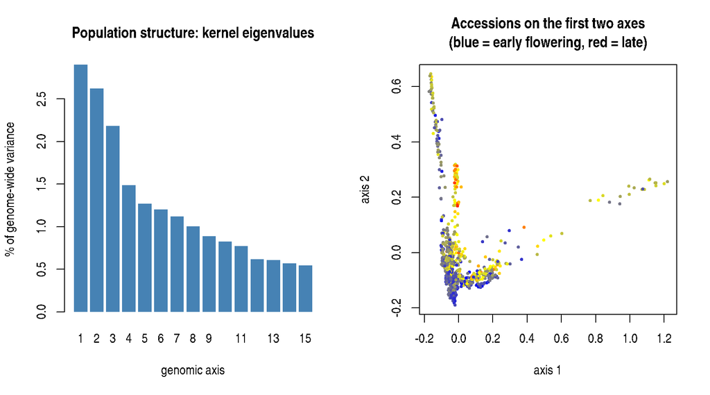

```r
eK <- eigen(Kfull, symmetric = TRUE)
pcs5 <- sweep(eK$vectors[, 1:5], 2, sqrt(eK$values[1:5]), "*")        # top genomic axes (ancestry gradients)
var_share <- eK$values / sum(eK$values)
col_ft <- colorRampPalette(c("blue", "yellow", "red"))(100)[cut(y_all, 100, labels = FALSE)]
par(mfrow = c(1, 2))
barplot(100 * var_share[1:15], names.arg = 1:15, col = "steelblue", border = NA, xlab = "genomic axis",
        ylab = "% of genome-wide variance", main = "Population structure: kernel eigenvalues")
plot(pcs5[, 1], pcs5[, 2], pch = 16, cex = 0.6, col = col_ft, xlab = "axis 1", ylab = "axis 2",
     main = "Accessions on the first two axes\n(blue = early flowering, red = late)")
```

```r
par(mfrow = c(1, 1))
cat(sprintf("The first axis alone carries %.1f%% of genome-wide variance; the first five carry %.1f%%.\n",
            100 * var_share[1], 100 * sum(var_share[1:5])))
```

```
## The first axis alone carries 2.9% of genome-wide variance; the first five carry 10.5%.
```

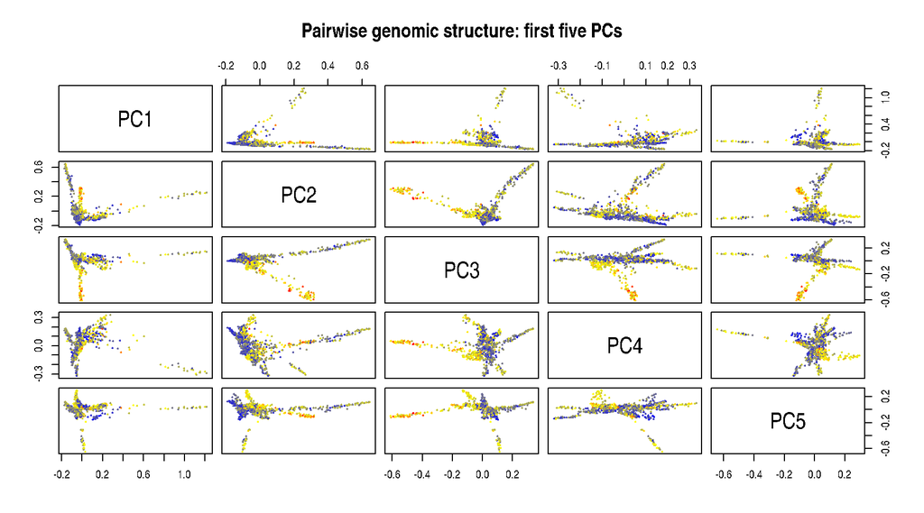

```r
# Pairwise visualization of the first five genomic PCs

pairs(
  pcs5,
  labels = paste0("PC", 1:5),
  pch = 16,
  col = col_ft,
  cex = 0.5,
  gap = 0.7,
  main = "Pairwise genomic structure: first five PCs"
)
```

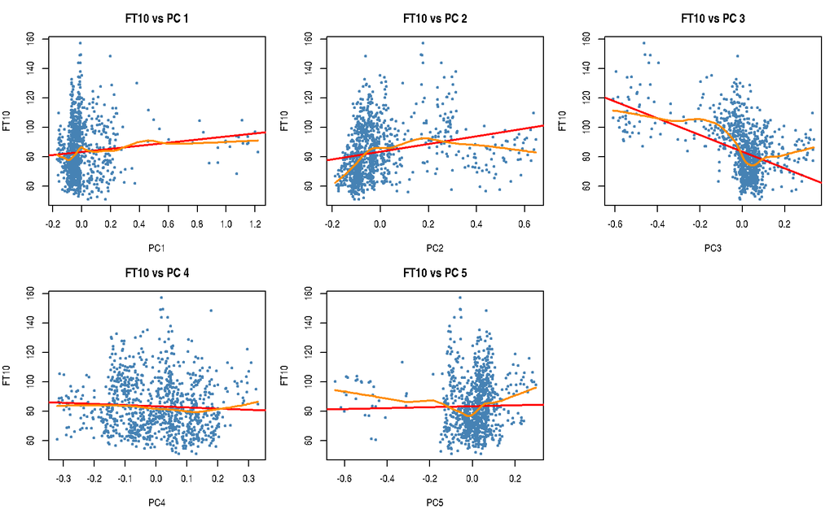

```r
# Relationship between the first five genomic axes and FT10

par(mfrow = c(2, 3), mar = c(4, 4, 3, 1))

for (j in 1:5) {

  plot(
    pcs5[, j],
    y_all,
    pch = 16,
    cex = 0.55,
    col = "steelblue",
    xlab = paste0("PC", j),
    ylab = "FT10",
    main = paste("FT10 vs PC", j)
  )

  # Linear relationship
  abline(
    lm(y_all ~ pcs5[, j]),
    col = "red",
    lwd = 2
  )

  # Smooth relationship
  lines(
    lowess(pcs5[, j], y_all),
    col = "darkorange",
    lwd = 2
  )
}

par(mfrow = c(1, 1))
```

```r
pc_ft_cor <- cor(pcs5, y_all, use = "complete.obs")

data.frame(
  Axis = paste0("PC", 1:5),
  Correlation_with_FT10 = round(as.numeric(pc_ft_cor), 3)
)
```

```
##   Axis Correlation_with_FT10
## 1  PC1                 0.099
## 2  PC2                 0.238
## 3  PC3                -0.470
## 4  PC4                -0.052
## 5  PC5                 0.020
```

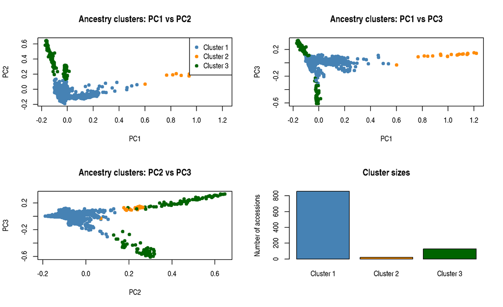

```r
grp <- kmeans(pcs5, centers = K_GROUPS, nstart = 25)$cluster
cluster_cols <- c(
  "steelblue",
  "darkorange",
  "darkgreen"
)

par(mfrow = c(2, 2))

plot(
  pcs5[, 1], pcs5[, 2],
  col = cluster_cols[grp],
  pch = 16,
  xlab = "PC1",
  ylab = "PC2",
  main = "Ancestry clusters: PC1 vs PC2"
)

legend(
  "topright",
  legend = paste("Cluster", 1:3),
  col = cluster_cols,
  pch = 16
)

plot(
  pcs5[, 1], pcs5[, 3],
  col = cluster_cols[grp],
  pch = 16,
  xlab = "PC1",
  ylab = "PC3",
  main = "Ancestry clusters: PC1 vs PC3"
)

plot(
  pcs5[, 2], pcs5[, 3],
  col = cluster_cols[grp],
  pch = 16,
  xlab = "PC2",
  ylab = "PC3",
  main = "Ancestry clusters: PC2 vs PC3"
)

barplot(
  table(grp),
  names.arg = paste("Cluster", 1:3),
  col = cluster_cols,
  ylab = "Number of accessions",
  main = "Cluster sizes"
)
```

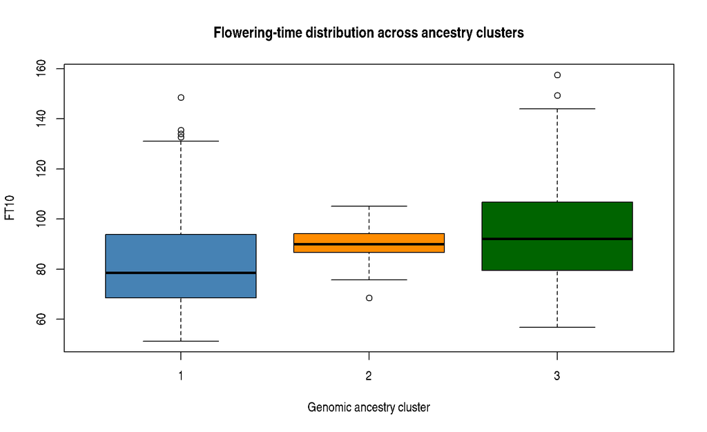

```r
par(mfrow = c(1, 1))
boxplot(
  y_all ~ factor(grp),
  col = cluster_cols,
  xlab = "Genomic ancestry cluster",
  ylab = "FT10",
  main = "Flowering-time distribution across ancestry clusters"
)
```

### Interpretation

The exploratory analysis suggests that genomic population structure and flowering-time variation are related but not equivalent.

Although differences in average FT10 are observed across the genotype-defined clusters, the substantial overlap between their phenotypic distributions indicates that these clusters do not provide a clear separation of accessions according to flowering time.

Thus, genomic ancestry alone does not appear sufficient to characterize the flowering-time phenotype. Considerable phenotypic heterogeneity remains within the genomic clusters.

These results motivate examining genomic relationships and population structure as potential sources of variation in prediction, rather than assuming that genotype-defined clusters correspond directly to distinct phenotypic groups.

```r
cluster_summary <- data.frame(
  Cluster = paste0("Cluster ", 1:K_GROUPS),
  N = as.integer(table(factor(grp, levels = 1:K_GROUPS))),
  Mean_FT10 = as.numeric(
    tapply(
      y_all,
      factor(grp, levels = 1:K_GROUPS),
      mean
    )
  ),
  Colour = cluster_cols
)

print(cluster_summary)
```

```
##     Cluster   N Mean_FT10     Colour
## 1 Cluster 1 855  81.77076  steelblue
## 2 Cluster 2  20  89.65000 darkorange
## 3 Cluster 3 128  94.76628  darkgreen
```

### 3.2 PCA analysis:

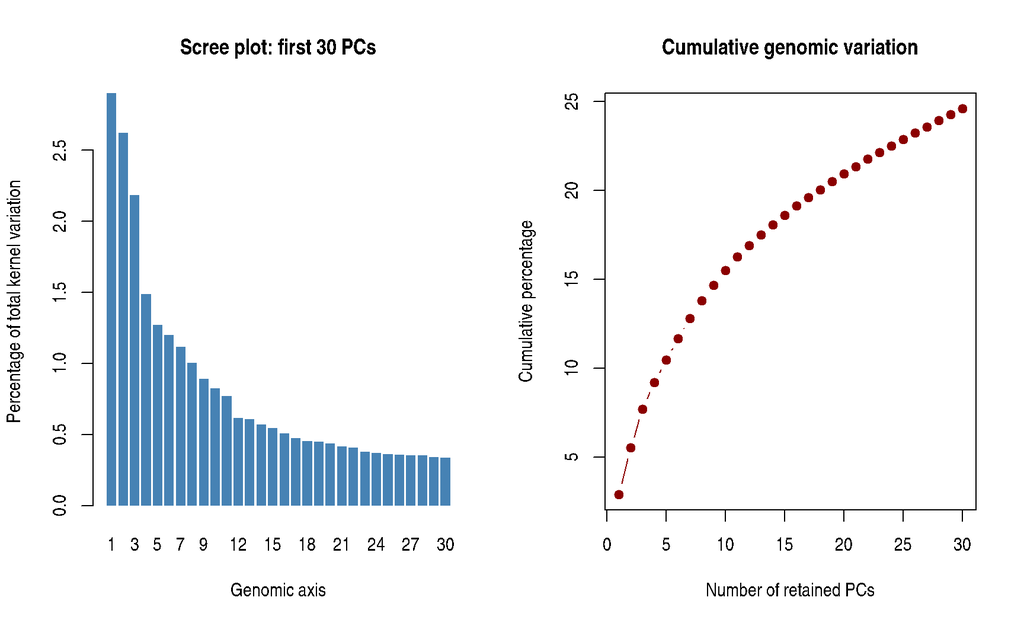

```r
# Retain the first 20 genomic principal coordinates

N_PC <- 20L

pcs20 <- sweep(
  eK$vectors[, 1:N_PC, drop = FALSE],
  2,
  sqrt(eK$values[1:N_PC]),
  "*"
)

colnames(pcs20) <- paste0("PC", 1:N_PC)

# Retain existing first-five-PC object for compatibility
pcs5 <- pcs20[, 1:5, drop = FALSE]


# Percentage of total genomic kernel variation

pc_percent <- 100 * var_share

N_SHOW <- 30

par(mfrow = c(1, 2))

# Individual variance shares
barplot(
  pc_percent[1:N_SHOW],
  names.arg = 1:N_SHOW,
  col = "steelblue",
  border = NA,
  xlab = "Genomic axis",
  ylab = "Percentage of total kernel variation",
  main = "Scree plot: first 30 PCs"
)

# Cumulative variance
plot(
  1:N_SHOW,
  cumsum(pc_percent)[1:N_SHOW],
  type = "b",
  pch = 19,
  col = "darkred",
  xlab = "Number of retained PCs",
  ylab = "Cumulative percentage",
  main = "Cumulative genomic variation"
)
```

```r
par(mfrow = c(1, 1))
# Pearson and Spearman correlations with FT10

pearson_cor <- sapply(
  1:N_PC,
  function(j) cor(pcs20[, j], y_all, use = "complete.obs")
)

spearman_cor <- sapply(
  1:N_PC,
  function(j) cor(
    pcs20[, j],
    y_all,
    method = "spearman",
    use = "complete.obs"
  )
)

pc_cor_table <- data.frame(
  PC = paste0("PC", 1:N_PC),
  Pearson = round(pearson_cor, 3),
  Spearman = round(spearman_cor, 3)
)

print(pc_cor_table)
```

```
##      PC Pearson Spearman
## 1   PC1   0.099    0.146
## 2   PC2   0.238    0.393
## 3   PC3  -0.470   -0.423
## 4   PC4  -0.052   -0.086
## 5   PC5   0.020    0.127
## 6   PC6  -0.036   -0.129
## 7   PC7   0.334    0.367
## 8   PC8   0.146    0.261
## 9   PC9   0.160    0.134
## 10 PC10   0.038   -0.066
## 11 PC11   0.151    0.122
## 12 PC12  -0.009   -0.062
## 13 PC13  -0.131   -0.200
## 14 PC14   0.132    0.222
## 15 PC15   0.057    0.157
## 16 PC16  -0.103    0.037
## 17 PC17  -0.191   -0.189
## 18 PC18   0.064    0.017
## 19 PC19   0.013    0.001
## 20 PC20   0.027   -0.001
```

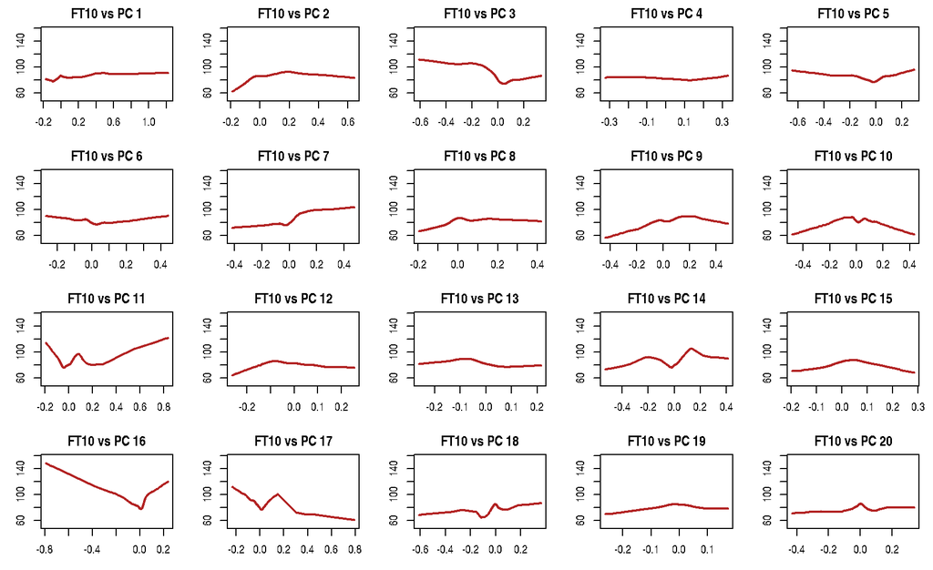

```r
par(
  mfrow = c(4, 5),
  mar = c(3, 3, 2, 1)
)

for (j in 1:N_PC) {

  plot(
    pcs20[, j],
    y_all,
    pch = 16,
    cex = 0.35,
    col = rgb(0.1, 0.35, 0.7, 0.4),
    xlab = paste0("PC", j),
    ylab = "FT10",
    main = paste("FT10 vs PC", j)
  )

  lines(
    lowess(pcs20[, j], y_all),
    col = "firebrick",
    lwd = 2
  )
}
```

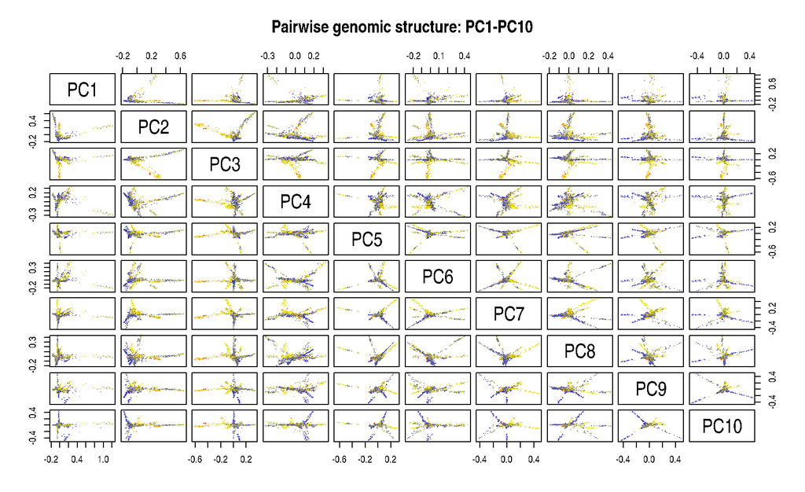

```r
par(mfrow = c(1, 1))

pairs(
  pcs20[, 1:10, drop = FALSE],
  pch = 16,
  col = col_ft,
  cex = 0.3,
  gap = 0.5,
  main = "Pairwise genomic structure: PC1-PC10"
)
```

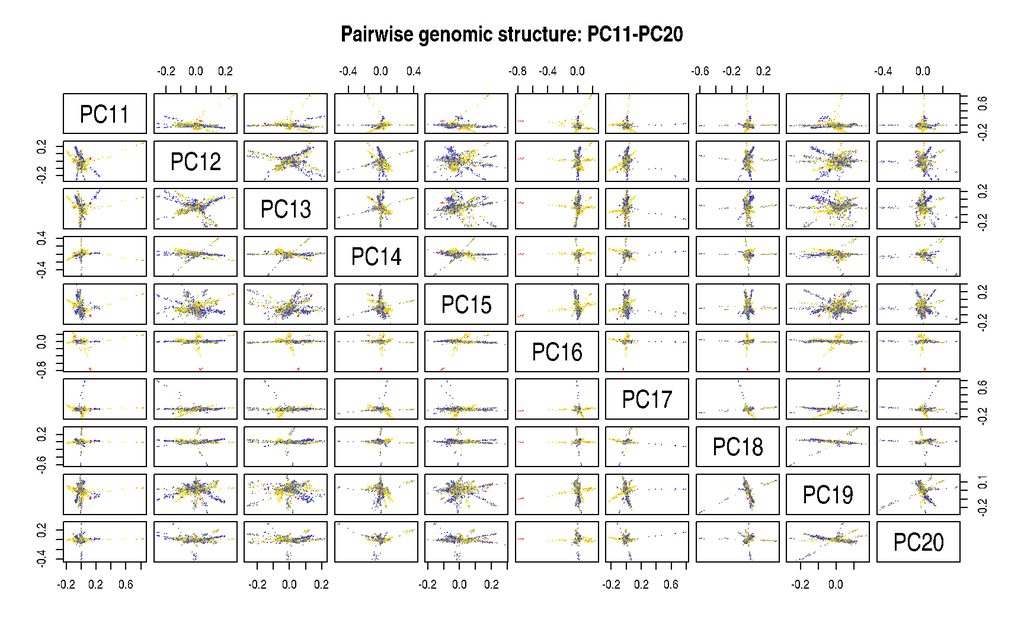

```r
pairs(
  pcs20[, 11:20, drop = FALSE],
  pch = 16,
  col = col_ft,
  cex = 0.3,
  gap = 0.5,
  main = "Pairwise genomic structure: PC11-PC20"
)
```

```r
# ================================================================
# EXTENDED GENOMIC PCA ANALYSIS: FIRST 100 PRINCIPAL COMPONENTS
# ================================================================

N_PC <- 100L

stopifnot(length(eK$values) >= N_PC)
stopifnot(all(eK$values[1:N_PC] > 0))
stopifnot(length(y_all) == nrow(G2))
stopifnot(all(is.finite(y_all)))

# ------------------------------------------------
# 1. Construct the first 100 genomic PC coordinates
# ------------------------------------------------

pcs100 <- sweep(
  eK$vectors[, 1:N_PC, drop = FALSE],
  2,
  sqrt(eK$values[1:N_PC]),
  "*"
)

colnames(pcs100) <- paste0("PC", 1:N_PC)

cat("PC matrix dimensions:", dim(pcs100), "\n")


# ------------------------------------------------
# 2. Genomic variance explained
# ------------------------------------------------

pc_percent <- 100 * var_share

pc_variance_table <- data.frame(
  PC = paste0("PC", 1:N_PC),
  Eigenvalue = eK$values[1:N_PC],
  Variance_percent = pc_percent[1:N_PC],
  Cumulative_percent = cumsum(pc_percent)[1:N_PC]
)

cat("\nFIRST 20 GENOMIC AXES:\n")
print(head(pc_variance_table, 20), row.names = FALSE)

cat("\nCUMULATIVE VARIANCE EXPLAINED:\n")

for (k in c(2, 5, 10, 20, 30, 50, 75, 100)) {
  cat(
    k, "PCs:",
    round(sum(pc_percent[1:k]), 3),
    "%\n"
  )
}
```

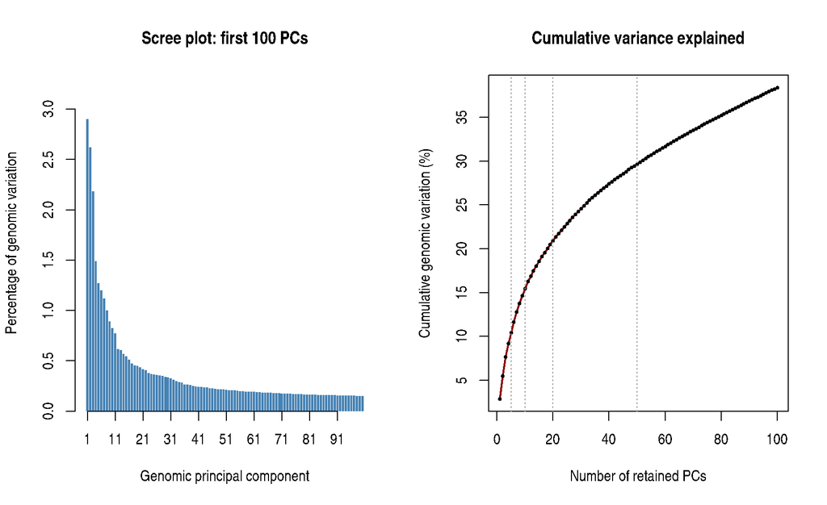

```r
# ------------------------------------------------
# 3. Scree plot and cumulative variance plot
# ------------------------------------------------

par(mfrow = c(1, 2))

bp <- barplot(
  pc_percent[1:N_PC],
  names.arg = rep("", N_PC),
  col = "steelblue",
  border = NA,
  ylim = c(0, max(pc_percent[1:N_PC]) * 1.15),
  xlab = "Genomic principal component",
  ylab = "Percentage of genomic variation",
  main = "Scree plot: first 100 PCs"
)

axis(
  1,
  at = bp[seq(1, N_PC, by = 10)],
  labels = seq(1, N_PC, by = 10)
)

plot(
  1:N_PC,
  cumsum(pc_percent)[1:N_PC],
  type = "l",
  lwd = 2,
  col = "darkred",
  xlab = "Number of retained PCs",
  ylab = "Cumulative genomic variation (%)",
  main = "Cumulative variance explained"
)

points(
  1:N_PC,
  cumsum(pc_percent)[1:N_PC],
  pch = 16,
  cex = 0.5
)

abline(
  v = c(5, 10, 20, 50),
  lty = 3,
  col = "grey60"
)
```

```r
par(mfrow = c(1, 1))


# ------------------------------------------------
# 4. Pearson and Spearman correlations with FT10
# ------------------------------------------------

pearson_cor <- vapply(
  1:N_PC,
  function(j) {
    cor(pcs100[, j], y_all, method = "pearson")
  },
  numeric(1)
)

spearman_cor <- vapply(
  1:N_PC,
  function(j) {
    cor(pcs100[, j], y_all, method = "spearman")
  },
  numeric(1)
)


# ------------------------------------------------
# 5. Pearson correlation tests and BH adjustment
# ------------------------------------------------

pearson_p <- vapply(
  1:N_PC,
  function(j) {
    cor.test(
      pcs100[, j],
      y_all,
      method = "pearson"
    )$p.value
  },
  numeric(1)
)

pearson_p_BH <- p.adjust(
  pearson_p,
  method = "BH"
)


# ------------------------------------------------
# 6. Combined summary table
# ------------------------------------------------

pc_summary100 <- data.frame(

  PC = paste0("PC", 1:N_PC),

  Genomic_variance_pct =
    round(pc_percent[1:N_PC], 4),

  Cumulative_genomic_pct =
    round(cumsum(pc_percent)[1:N_PC], 3),

  Pearson_FT10 =
    round(pearson_cor, 3),

  Spearman_FT10 =
    round(spearman_cor, 3),

  Pearson_p =
    signif(pearson_p, 4),

  Pearson_BH =
    signif(pearson_p_BH, 4)
)

cat("\nCOMPLETE 100-PC SUMMARY:\n")
```

```
##
## COMPLETE 100-PC SUMMARY:
```

```r
print(pc_summary100, row.names = FALSE)
```

```
##     PC Genomic_variance_pct Cumulative_genomic_pct Pearson_FT10 Spearman_FT10
##    PC1               2.9019                  2.902        0.099         0.146
##    PC2               2.6207                  5.523        0.238         0.393
##    PC3               2.1838                  7.706       -0.470        -0.423
##    PC4               1.4877                  9.194       -0.052        -0.086
##    PC5               1.2705                 10.465        0.020         0.127
##    PC6               1.2009                 11.665       -0.036        -0.129
##    PC7               1.1183                 12.784        0.334         0.367
##    PC8               1.0020                 13.786        0.146         0.261
##    PC9               0.8893                 14.675        0.160         0.134
##   PC10               0.8249                 15.500        0.038        -0.066
##   PC11               0.7714                 16.271        0.151         0.122
##   PC12               0.6175                 16.889       -0.009        -0.062
##   PC13               0.6070                 17.496       -0.131        -0.200
##   PC14               0.5687                 18.065        0.132         0.222
##   PC15               0.5452                 18.610        0.057         0.157
##   PC16               0.5089                 19.119       -0.103         0.037
##   PC17               0.4728                 19.591       -0.191        -0.189
##   PC18               0.4551                 20.047        0.064         0.017
##   PC19               0.4485                 20.495        0.013         0.001
##   PC20               0.4353                 20.930        0.027        -0.001
##   PC21               0.4161                 21.347       -0.060        -0.027
##   PC22               0.4064                 21.753       -0.115        -0.107
##   PC23               0.3782                 22.131        0.047        -0.125
##   PC24               0.3710                 22.502       -0.083        -0.069
##   PC25               0.3623                 22.864        0.001        -0.016
##   PC26               0.3587                 23.223        0.119         0.121
##   PC27               0.3529                 23.576        0.012         0.019
##   PC28               0.3517                 23.928       -0.005        -0.043
##   PC29               0.3400                 24.268        0.047         0.085
##   PC30               0.3351                 24.603        0.016         0.042
##   PC31               0.3282                 24.931       -0.007        -0.020
##   PC32               0.3141                 25.245        0.040         0.057
##   PC33               0.2995                 25.545        0.018        -0.002
##   PC34               0.2862                 25.831        0.066         0.031
##   PC35               0.2855                 26.116       -0.082        -0.093
##   PC36               0.2666                 26.383        0.004         0.009
##   PC37               0.2624                 26.646        0.086         0.089
##   PC38               0.2580                 26.903        0.056         0.000
##   PC39               0.2485                 27.152       -0.039        -0.034
```

[output cut: 147 more lines]

```
##  3.449e-01  6.508e-01
##  5.531e-02  2.048e-01
##  2.927e-01  6.050e-01
##  1.711e-01  4.503e-01
##  1.371e-01  3.706e-01
##  4.154e-01  7.041e-01
##  9.581e-01  9.934e-01
##  4.392e-01  7.201e-01
##  8.849e-01  9.766e-01
##  2.090e-01  4.861e-01
##  9.006e-01  9.766e-01
##  5.000e-01  7.555e-01
##  7.760e-01  9.276e-01
##  9.985e-02  3.125e-01
##  3.199e-01  6.272e-01
```

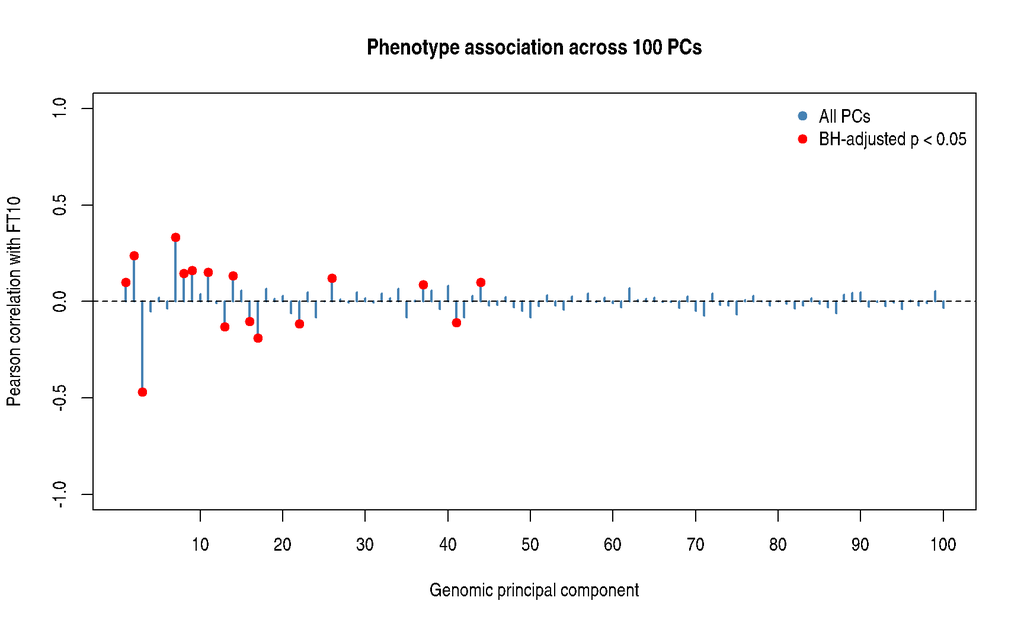

```r
# ------------------------------------------------
# 7. Plot Pearson correlations across 100 PCs
# ------------------------------------------------

plot(
  1:N_PC,
  pearson_cor,
  type = "h",
  lwd = 2,
  col = "steelblue",
  ylim = c(-1, 1),
  xaxt = "n",
  xlab = "Genomic principal component",
  ylab = "Pearson correlation with FT10",
  main = "Phenotype association across 100 PCs"
)

axis(
  1,
  at = seq(10, 100, by = 10),
  labels = seq(10, 100, by = 10)
)

abline(h = 0, lty = 2)

# Highlight PCs with BH-adjusted p < 0.05
sig <- which(pearson_p_BH < 0.05)

points(
  sig,
  pearson_cor[sig],
  pch = 19,
  col = "red",
  cex = 1
)

legend(
  "topright",
  legend = c(
    "All PCs",
    "BH-adjusted p < 0.05"
  ),
  col = c("steelblue", "red"),
  pch = 19,
  bty = "n"
)
```

```r
# ------------------------------------------------
# 8. Identify the 20 strongest marginal associations
# ------------------------------------------------

top_pc <- order(
  abs(pearson_cor),
  decreasing = TRUE
)[1:20]

top_pc_table <- pc_summary100[top_pc, ]

top_pc_table <- top_pc_table[
  order(
    abs(top_pc_table$Pearson_FT10),
    decreasing = TRUE
  ),
]

cat("\n20 PCs WITH STRONGEST PEARSON ASSOCIATIONS:\n")
```

```
##
## 20 PCs WITH STRONGEST PEARSON ASSOCIATIONS:
```

```r
print(top_pc_table, row.names = FALSE)
```

```
##    PC Genomic_variance_pct Cumulative_genomic_pct Pearson_FT10 Spearman_FT10
##   PC3               2.1838                  7.706       -0.470        -0.423
##   PC7               1.1183                 12.784        0.334         0.367
##   PC2               2.6207                  5.523        0.238         0.393
##  PC17               0.4728                 19.591       -0.191        -0.189
##   PC9               0.8893                 14.675        0.160         0.134
##  PC11               0.7714                 16.271        0.151         0.122
##   PC8               1.0020                 13.786        0.146         0.261
##  PC14               0.5687                 18.065        0.132         0.222
##  PC13               0.6070                 17.496       -0.131        -0.200
##  PC26               0.3587                 23.223        0.119         0.121
##  PC22               0.4064                 21.753       -0.115        -0.107
##  PC41               0.2414                 27.640       -0.108        -0.106
##  PC16               0.5089                 19.119       -0.103         0.037
##  PC44               0.2352                 28.350        0.099         0.120
##   PC1               2.9019                  2.902        0.099         0.146
##  PC37               0.2624                 26.646        0.086         0.089
##  PC24               0.3710                 22.502       -0.083        -0.069
##  PC35               0.2855                 26.116       -0.082        -0.093
##  PC50               0.2148                 29.673       -0.082        -0.162
##  PC42               0.2388                 27.879       -0.081        -0.074
##  Pearson_p Pearson_BH
##  3.839e-56  3.839e-54
##  1.398e-27  6.992e-26
##  2.318e-14  7.726e-13
##  1.104e-09  2.760e-08
##  3.661e-07  7.322e-06
##  1.444e-06  2.406e-05
##  3.430e-06  4.899e-05
##  2.834e-05  3.542e-04
##  3.220e-05  3.578e-04
##  1.530e-04  1.530e-03
##  2.567e-04  2.333e-03
##  5.859e-04  4.883e-03
##  1.124e-03  8.646e-03
##  1.719e-03  1.148e-02
##  1.722e-03  1.148e-02
##  6.469e-03  4.043e-02
##  8.715e-03  5.031e-02
##  9.730e-03  5.031e-02
##  9.765e-03  5.031e-02
##  1.006e-02  5.031e-02
```

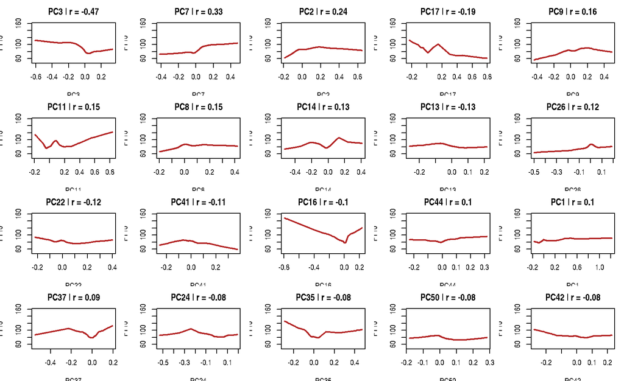

```r
# ------------------------------------------------
# 9. Plot FT10 against the 20 strongest PCs
# ------------------------------------------------

par(
  mfrow = c(4, 5),
  mar = c(3.5, 3.5, 2.5, 1)
)

for (j in top_pc) {

  plot(
    pcs100[, j],
    y_all,
    pch = 16,
    cex = 0.4,
    col = rgb(0.1, 0.35, 0.7, 0.4),
    xlab = paste0("PC", j),
    ylab = "FT10",
    main = paste0(
      "PC", j,
      " | r = ",
      round(pearson_cor[j], 2)
    )
  )

  lines(
    lowess(pcs100[, j], y_all),
    col = "firebrick",
    lwd = 2
  )
}
```

```r
par(mfrow = c(1, 1))


# ------------------------------------------------
# 10. Linear regression using the first 100 PCs
# ------------------------------------------------

pc_df100 <- as.data.frame(pcs100)

pc_fit100 <- lm(
  y_all ~ .,
  data = pc_df100
)

R2_pc100 <- summary(pc_fit100)$r.squared

# Because PC scores are mutually orthogonal,
# this should agree with the sum of squared correlations.

R2_from_correlations <- sum(pearson_cor^2)

cat("\nIN-SAMPLE LINEAR REGRESSION RESULTS:\n")
```

```
##
## IN-SAMPLE LINEAR REGRESSION RESULTS:
```

```r
cat(
  "R-squared using first 100 PCs:",
  round(R2_pc100, 4),
  "\n"
)
```

```
## R-squared using first 100 PCs: 0.7275
```

```r
cat(
  "Sum of squared PC correlations:",
  round(R2_from_correlations, 4),
  "\n"
)
```

```
## Sum of squared PC correlations: 0.7275
```

```r
cat(
  "Difference:",
  abs(R2_pc100 - R2_from_correlations),
  "\n"
)
```

```
## Difference: 3.330669e-16
```

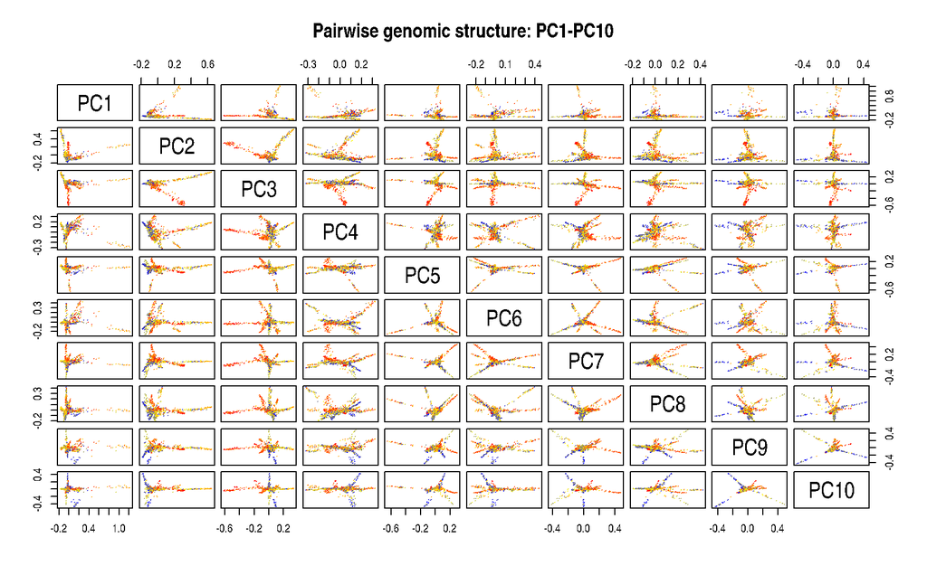

```r
# ------------------------------------------------
# 11. Pairwise plots: first 10 and PCs 11-20
# ------------------------------------------------

# Create colour gradient using flowering-time ranks

ft_rank <- rank(
  y_all,
  ties.method = "average"
)

ft_bin <- pmin(
  100,
  ceiling(100 * ft_rank / length(ft_rank))
)

pc_cols <- colorRampPalette(
  c("blue", "yellow", "red")
)(100)[ft_bin]


pairs(
  pcs100[, 1:10, drop = FALSE],
  pch = 16,
  col = pc_cols,
  cex = 0.3,
  gap = 0.5,
  main = "Pairwise genomic structure: PC1-PC10"
)
```

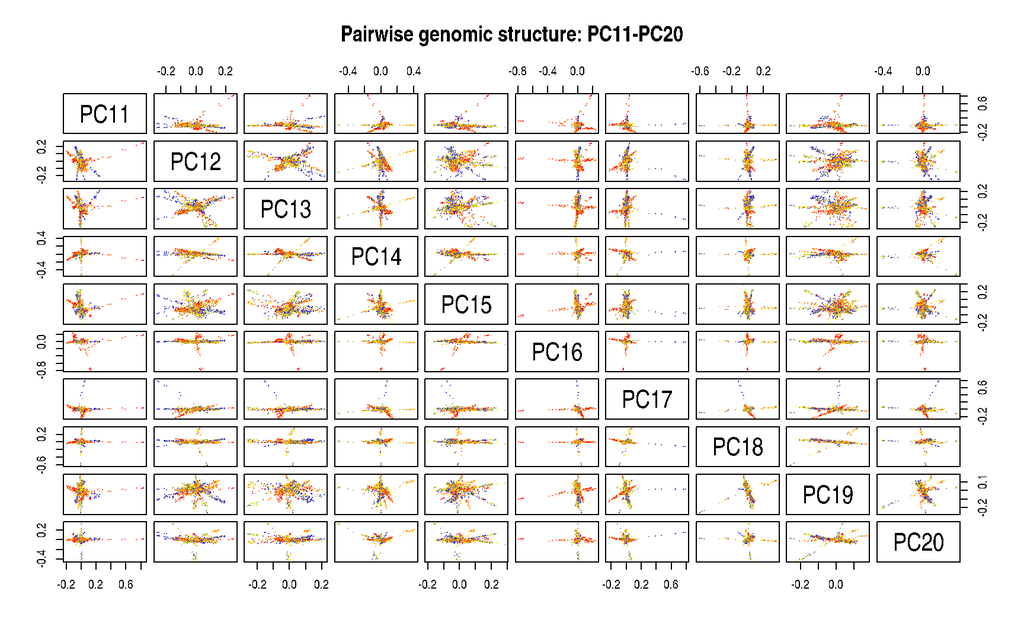

```r
pairs(
  pcs100[, 11:20, drop = FALSE],
  pch = 16,
  col = pc_cols,
  cex = 0.3,
  gap = 0.5,
  main = "Pairwise genomic structure: PC11-PC20"
)
```

```r
# ------------------------------------------------
# 12. Save the results
# ------------------------------------------------

saveRDS(
  list(
    pcs100 = pcs100,
    variance_table = pc_variance_table,
    correlation_table = pc_summary100,
    top_pc_table = top_pc_table,
    regression_R2 = R2_pc100
  ),
  file = "pc100_exploratory_results.rds"
)

cat("\n100-PC exploratory analysis completed.\n")
```

```
##
## 100-PC exploratory analysis completed.
```

### Phenotype associations across the first 100 genomic axes

### Extended analysis of genomic structure and flowering-time associations

To investigate genomic variation beyond the leading principal components, the first 100 eigenvectors of the genome-wide relationship matrix were examined. The cumulative proportion of genomic variation explained increases gradually, reaching 38.38% for the first 100 components, compared with 5.52% for the first two and 20.93% for the first 20 components. This indicates that genomic variation in the accession panel is distributed across multiple dimensions rather than being concentrated in only a few leading axes.

Pearson and Spearman correlations were calculated between each of the first 100 genomic PC scores and FT10. Among these components, PC3 exhibits the strongest marginal linear association with flowering time (Pearson correlation = -0.470; Spearman correlation = -0.423), followed by PC7 (0.334; 0.367) and PC2 (0.238; 0.393). Several additional components, including PC17, PC22, PC26, PC37 and PC41, also exhibit statistically detectable marginal associations after Benjamini–Hochberg adjustment for multiple testing. Overall, 16 of the 100 components have BH-adjusted Pearson correlation p-values below 0.05.

An ordinary least-squares regression of FT10 on the first 100 genomic PCs produces an in-sample $R^2$ of 0.7275. Because the PC scores are mutually orthogonal, this value equals the sum of their squared marginal Pearson correlations. This result indicates a substantial joint linear association between the genomic coordinates and flowering time within the observed accession panel. It should not, however, be interpreted as heritability, causal ancestry effects or out-of-sample predictive performance.

Taken together, these analyses show that flowering-time variation is associated with multiple dimensions of genome-wide genetic variation, including some lower-ranked components that explain relatively small proportions of total genomic variation. These findings motivate further investigation of population structure, genetic relatedness and their potential influence on SNP screening and genomic prediction.

```r
# ============================================================
# INTERACTIVE 3D GENOMIC PCA: PC1, PC3 AND PC7
# COLOURING: FLOWERING TIME AT 10 DEGREES C (FT10)
# ============================================================

# Check that the PCA coordinates and phenotype are aligned
stopifnot(nrow(pcs100) == length(y_all))
stopifnot(length(fam$sample.ID) == length(y_all))
stopifnot(all(is.finite(y_all)))

# Construct plotting data
pca3d <- data.frame(
  accession_id = as.character(fam$sample.ID),
  FT10 = as.numeric(y_all),
  PC1 = as.numeric(pcs100[, "PC1"]),
  PC3 = as.numeric(pcs100[, "PC3"]),
  PC7 = as.numeric(pcs100[, "PC7"])
)

# Percentage of total genomic variation explained
pc_var <- 100 * eK$values / sum(eK$values)

# Interactive 3D scatter plot
p_pca3d <- plotly::plot_ly(
  data = pca3d,

  x = ~PC1,
  y = ~PC3,
  z = ~PC7,

  type = "scatter3d",
  mode = "markers",

  # Continuous colour gradient based on FT10
  color = ~FT10,
  colors = c(
  "#B2182B",  # Deep red
  "#E34A33",  # Red-orange
  "#F46D43",  # Orange
  "#FDAE61",  # Amber
  "#FFFF00"   # Bright yellow
),

  marker = list(
    size = 3,
    opacity = 0.80,
    showscale = TRUE,
    colorbar = list(
      title = "FT10 (days)"
    )
  ),

  # Information displayed when hovering
  text = ~paste0(
    "Accession: ", accession_id,
    "<br>FT10: ", round(FT10, 2), " days"
  ),

  hovertemplate = paste0(
    "%{text}",
    "<br>PC1: %{x:.3f}",
    "<br>PC3: %{y:.3f}",
    "<br>PC7: %{z:.3f}",
    "<extra></extra>"
  )
) |>

  plotly::layout(

    title = list(
      text = "Genomic population structure and flowering time",
      x = 0.5
    ),

    scene = list(

      xaxis = list(
        title = paste0("PC1 (", round(pc_var[1], 2), "%)")
      ),

      yaxis = list(
        title = paste0("PC3 (", round(pc_var[3], 2), "%)")
      ),

      zaxis = list(
        title = paste0("PC7 (", round(pc_var[7], 2), "%)")
      ),

      aspectmode = "data"
    ),

    margin = list(l = 0, r = 0, b = 0, t = 60)
  ) |>

  plotly::config(
    displayModeBar = TRUE,
    displaylogo = FALSE,
    responsive = TRUE
  )

p_pca3d
```

[interactive chart not shown]

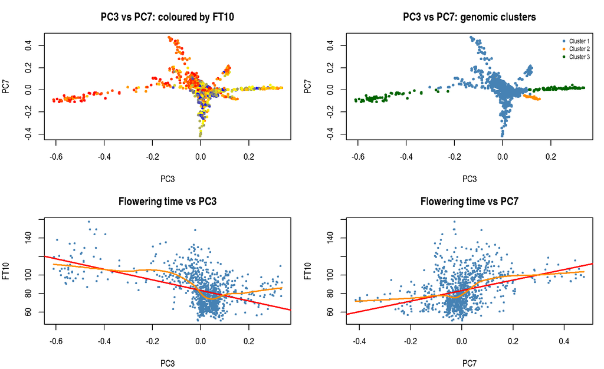

```r
# ============================================================
# INVESTIGATION OF PC3 AND PC7
# ============================================================

pc3 <- as.numeric(pcs100[, 3])
pc7 <- as.numeric(pcs100[, 7])

stopifnot(length(pc3) == length(y_all))
stopifnot(length(pc7) == length(y_all))


# ------------------------------------------------------------
# 1. Create flowering-time colours
# ------------------------------------------------------------

ft_rank <- rank(y_all, ties.method = "average")

ft_bin <- pmin(
  100,
  ceiling(100 * ft_rank / length(ft_rank))
)

ft_cols <- colorRampPalette(
  c("blue", "yellow", "red")
)(100)[ft_bin]


# ------------------------------------------------------------
# 2. PC3 against PC7
# ------------------------------------------------------------

par(mfrow = c(2, 2), mar = c(4, 4, 3, 1))

# Colour by flowering time
plot(
  pc3, pc7,
  col = ft_cols,
  pch = 16,
  cex = 0.65,
  xlab = "PC3",
  ylab = "PC7",
  main = "PC3 vs PC7: coloured by FT10"
)

# Colour by existing genomic clusters
plot(
  pc3, pc7,
  col = cluster_cols[grp],
  pch = 16,
  cex = 0.65,
  xlab = "PC3",
  ylab = "PC7",
  main = "PC3 vs PC7: genomic clusters"
)

legend(
  "topright",
  legend = paste("Cluster", 1:K_GROUPS),
  col = cluster_cols,
  pch = 16,
  cex = 0.7,
  bty = "n"
)


# PC3 against FT10
plot(
  pc3, y_all,
  pch = 16,
  cex = 0.55,
  col = "steelblue",
  xlab = "PC3",
  ylab = "FT10",
  main = "Flowering time vs PC3"
)

abline(
  lm(y_all ~ pc3),
  col = "red",
  lwd = 2
)

lines(
  lowess(pc3, y_all),
  col = "darkorange",
  lwd = 2
)


# PC7 against FT10
plot(
  pc7, y_all,
  pch = 16,
  cex = 0.55,
  col = "steelblue",
  xlab = "PC7",
  ylab = "FT10",
  main = "Flowering time vs PC7"
)

abline(
  lm(y_all ~ pc7),
  col = "red",
  lwd = 2
)

lines(
  lowess(pc7, y_all),
  col = "darkorange",
  lwd = 2
)
```

```r
par(mfrow = c(1, 1))


# ------------------------------------------------------------
# 3. Joint association of PC3 and PC7 with FT10
# ------------------------------------------------------------

fit_pc37 <- lm(y_all ~ pc3 + pc7)

cat("\nJOINT PC3-PC7 REGRESSION:\n")
```

```
##
## JOINT PC3-PC7 REGRESSION:
```

```r
print(summary(fit_pc37))
```

```
##
## Call:
## lm(formula = y_all ~ pc3 + pc7)
##
## Residuals:
##     Min      1Q  Median      3Q     Max
## -31.324 -10.881  -2.190   9.675  59.270
##
## Coefficients:
##             Estimate Std. Error t value Pr(>|t|)
## (Intercept)  83.5863     0.4631  180.48   <2e-16 ***
## pc3         -56.9714     3.1355  -18.17   <2e-16 ***
## pc7          56.6467     4.3816   12.93   <2e-16 ***
## ---
## Signif. codes:  0 '***' 0.001 '**' 0.01 '*' 0.05 '.' 0.1 ' ' 1
##
## Residual standard error: 14.67 on 1000 degrees of freedom
## Multiple R-squared:  0.3321, Adjusted R-squared:  0.3308
## F-statistic: 248.6 on 2 and 1000 DF,  p-value: < 2.2e-16
```

```r
cat(
  "\nR-squared of PC3 alone:",
  round(cor(pc3, y_all)^2, 4)
)
```

```
##
## R-squared of PC3 alone: 0.2205
```

```r
cat(
  "\nR-squared of PC7 alone:",
  round(cor(pc7, y_all)^2, 4)
)
```

```
##
## R-squared of PC7 alone: 0.1116
```

```r
cat(
  "\nJoint R-squared:",
  round(summary(fit_pc37)$r.squared, 4),
  "\n"
)
```

```
##
## Joint R-squared: 0.3321
```

```r
# ------------------------------------------------------------
# 4. Identify extreme accessions
# ------------------------------------------------------------

score_data <- data.frame(
  Accession = as.character(fam$sample.ID),
  PC3 = pc3,
  PC7 = pc7,
  FT10 = y_all,
  Cluster = grp
)

cat("\n10 LOWEST PC3 ACCESSIONS:\n")
```

```
##
## 10 LOWEST PC3 ACCESSIONS:
```

```r
print(head(score_data[order(score_data$PC3), ], 10))
```

```
##     Accession        PC3         PC7      FT10 Cluster
## 509      9321 -0.6103462 -0.08750125 106.75000       3
## 197      6235 -0.6091712 -0.10204747 119.50000       3
## 543      9433 -0.5957989 -0.08237722 138.00000       3
## 121      6071 -0.5873334 -0.10629631 120.75000       3
## 199      6238 -0.5841853 -0.09186224 104.50000       3
## 174      6174 -0.5796765 -0.09165931 100.00000       3
## 120      6070 -0.5773145 -0.09980366 106.75000       3
## 171      6169 -0.5672811 -0.05163120 116.00000       3
## 119      6069 -0.5643350 -0.07125863 107.25000       3
## 96       6011 -0.5619833 -0.08355628  97.33333       3
```

```r
cat("\n10 HIGHEST PC3 ACCESSIONS:\n")
```

```
##
## 10 HIGHEST PC3 ACCESSIONS:
```

```r
print(tail(score_data[order(score_data$PC3), ], 10))
```

```
##     Accession       PC3        PC7      FT10 Cluster
## 674      9637 0.3055814 0.01992961  81.25000       3
## 678      9641 0.3066373 0.01676992  82.66667       3
## 658      9620 0.3119010 0.01329324  89.75000       3
## 677      9640 0.3145964 0.01788351  92.75000       3
## 669      9632 0.3177676 0.02006527  92.00000       3
## 668      9631 0.3197357 0.01357139  98.50000       3
## 673      9636 0.3296314 0.01816240 109.75000       3
## 680      9643 0.3310623 0.01926294  85.00000       3
## 657      9619 0.3330384 0.01935939  77.33333       3
## 659      9621 0.3354236 0.01938536  92.00000       3
```

```r
cat("\n10 LOWEST PC7 ACCESSIONS:\n")
```

```
##
## 10 LOWEST PC7 ACCESSIONS:
```

```r
print(head(score_data[order(score_data$PC7), ], 10))
```

```
##     Accession           PC3        PC7  FT10 Cluster
## 241      6927 -3.466770e-03 -0.4154437 73.50       1
## 410      7515 -1.543931e-03 -0.3990031 73.75       1
## 386      7377 -1.215882e-03 -0.3989955 75.75       1
## 347      7248 -5.467764e-04 -0.3980730 71.50       1
## 323      7160 -7.502218e-04 -0.3906905 72.25       1
## 289      7033 -7.149527e-05 -0.3708836 78.75       1
## 20        870 -4.260015e-03 -0.3433244 72.50       1
## 427      8233  4.150490e-03 -0.3291990 75.50       1
## 37       1853  1.302784e-02 -0.3179204 71.50       1
## 46       2278  8.537332e-03 -0.3027326 79.25       1
```

```r
cat("\n10 HIGHEST PC7 ACCESSIONS:\n")
```

```
##
## 10 HIGHEST PC7 ACCESSIONS:
```

```r
print(tail(score_data[order(score_data$PC7), ], 10))
```

```
##     Accession         PC3       PC7   FT10 Cluster
## 150      6125 -0.09941511 0.4202926 106.25       1
## 104      6023 -0.09357379 0.4244361  93.75       1
## 113      6040 -0.10890446 0.4254586  93.25       1
## 162      6145 -0.10614731 0.4417827 116.00       1
## 520      9380 -0.12682417 0.4447515 101.00       1
## 157      6136 -0.09576233 0.4450107  96.50       1
## 105      6024 -0.12052730 0.4567954 106.75       1
## 136      6104 -0.12730454 0.4631058 100.00       1
## 457      8335 -0.12443270 0.4651585 100.00       1
## 147      6118 -0.13258973 0.4753312  98.25       1
```

```r
# ------------------------------------------------------------
# 5. Sensitivity of correlations to individual accessions
# ------------------------------------------------------------

loo_cor <- function(x, y) {
  vapply(
    seq_along(y),
    function(i) cor(x[-i], y[-i]),
    numeric(1)
  )
}

loo_pc3 <- loo_cor(pc3, y_all)
loo_pc7 <- loo_cor(pc7, y_all)

cat("\nINFLUENCE DIAGNOSTICS:\n")
```

```
##
## INFLUENCE DIAGNOSTICS:
```

```r
cat(
  "PC3 full correlation:", round(cor(pc3, y_all), 4),
  "\nLeave-one-out range:",
  round(range(loo_pc3), 4),
  "\n"
)
```

```
## PC3 full correlation: -0.4696
## Leave-one-out range: -0.4745 -0.4628
```

```r
cat(
  "PC7 full correlation:", round(cor(pc7, y_all), 4),
  "\nLeave-one-out range:",
  round(range(loo_pc7), 4),
  "\n"
)
```

```
## PC7 full correlation: 0.3341
## Leave-one-out range: 0.33 0.3386
```

```r
# ============================================================
# WITHIN-CLUSTER VS BETWEEN-CLUSTER PC3/PC7 ASSOCIATIONS
# ============================================================

d37 <- data.frame(
  FT10 = y_all,
  PC3 = pc3,
  PC7 = pc7,
  Cluster = factor(grp)
)

# ------------------------------------------------------------
# 1. Summary statistics within each cluster
# ------------------------------------------------------------

cluster_stats <- do.call(
  rbind,
  lapply(levels(d37$Cluster), function(g) {

    d <- d37[d37$Cluster == g, ]

    data.frame(
      Cluster = g,
      N = nrow(d),

      Mean_FT10 = mean(d$FT10),
      SD_FT10 = sd(d$FT10),

      Mean_PC3 = mean(d$PC3),
      SD_PC3 = sd(d$PC3),

      Mean_PC7 = mean(d$PC7),
      SD_PC7 = sd(d$PC7),

      Pearson_PC3_FT10 =
        cor(d$PC3, d$FT10),

      Spearman_PC3_FT10 =
        cor(d$PC3, d$FT10, method = "spearman"),

      Pearson_PC7_FT10 =
        cor(d$PC7, d$FT10),

      Spearman_PC7_FT10 =
        cor(d$PC7, d$FT10, method = "spearman")
    )
  })
)

cat("\nWITHIN-CLUSTER SUMMARY:\n")
```

```
##
## WITHIN-CLUSTER SUMMARY:
```

```r
print(cluster_stats, row.names = FALSE)
```

```
##  Cluster   N Mean_FT10   SD_FT10    Mean_PC3     SD_PC3    Mean_PC7     SD_PC7
##        1 855  81.77076 16.988111  0.01201228 0.06036504  0.00478244 0.11235034
##        2  20  89.65000  8.880938  0.11342753 0.03823049 -0.05988359 0.03931410
##        3 128  94.76628 20.734002 -0.09796135 0.36729649 -0.02258839 0.04346412
##  Pearson_PC3_FT10 Spearman_PC3_FT10 Pearson_PC7_FT10 Spearman_PC7_FT10
##       -0.46630676       -0.42295490      0.463845089        0.53211372
##       -0.05724676       -0.02857143      0.001186912       -0.09924812
##       -0.71633529       -0.62234259     -0.649086473       -0.70521382
```

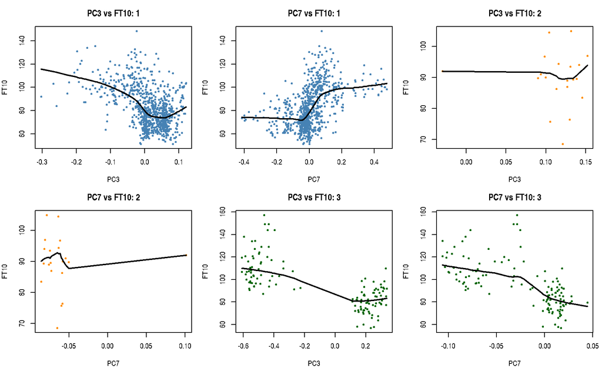

```r
# ------------------------------------------------------------
# 2. Visualize relationships separately by cluster
# ------------------------------------------------------------

par(
  mfrow = c(2, 3),
  mar = c(4, 4, 3, 1)
)

for (g in levels(d37$Cluster)) {

  d <- d37[d37$Cluster == g, ]

  plot(
    d$PC3,
    d$FT10,
    pch = 16,
    cex = 0.55,
    col = cluster_cols[as.integer(g)],
    xlab = "PC3",
    ylab = "FT10",
    main = paste("PC3 vs FT10:", g)
  )

  lines(
    lowess(d$PC3, d$FT10),
    col = "black",
    lwd = 2
  )

  plot(
    d$PC7,
    d$FT10,
    pch = 16,
    cex = 0.55,
    col = cluster_cols[as.integer(g)],
    xlab = "PC7",
    ylab = "FT10",
    main = paste("PC7 vs FT10:", g)
  )

  lines(
    lowess(d$PC7, d$FT10),
    col = "black",
    lwd = 2
  )
}
```

```r
par(mfrow = c(1, 1))


# ------------------------------------------------------------
# 3. Compare regressions with and without cluster effects
# ------------------------------------------------------------

fit_without_cluster <- lm(
  FT10 ~ PC3 + PC7,
  data = d37
)

fit_with_cluster <- lm(
  FT10 ~ PC3 + PC7 + Cluster,
  data = d37
)

cat("\nMODEL WITHOUT CLUSTER EFFECTS:\n")
```

```
##
## MODEL WITHOUT CLUSTER EFFECTS:
```

```r
print(summary(fit_without_cluster))
```

```
##
## Call:
## lm(formula = FT10 ~ PC3 + PC7, data = d37)
##
## Residuals:
##     Min      1Q  Median      3Q     Max
## -31.324 -10.881  -2.190   9.675  59.270
##
## Coefficients:
##             Estimate Std. Error t value Pr(>|t|)
## (Intercept)  83.5863     0.4631  180.48   <2e-16 ***
## PC3         -56.9714     3.1355  -18.17   <2e-16 ***
## PC7          56.6467     4.3816   12.93   <2e-16 ***
## ---
## Signif. codes:  0 '***' 0.001 '**' 0.01 '*' 0.05 '.' 0.1 ' ' 1
##
## Residual standard error: 14.67 on 1000 degrees of freedom
## Multiple R-squared:  0.3321, Adjusted R-squared:  0.3308
## F-statistic: 248.6 on 2 and 1000 DF,  p-value: < 2.2e-16
```

```r
cat("\nMODEL WITH CLUSTER EFFECTS:\n")
```

```
##
## MODEL WITH CLUSTER EFFECTS:
```

```r
print(summary(fit_with_cluster))
```

```
##
## Call:
## lm(formula = FT10 ~ PC3 + PC7 + Cluster, data = d37)
##
## Residuals:
##     Min      1Q  Median      3Q     Max
## -30.181 -10.364  -1.826   9.389  60.497
##
## Coefficients:
##             Estimate Std. Error t value Pr(>|t|)
## (Intercept)  82.1259     0.4884 168.154  < 2e-16 ***
## PC3         -53.7481     3.1595 -17.012  < 2e-16 ***
## PC7          60.7483     4.2797  14.194  < 2e-16 ***
## Cluster2     17.2585     3.2451   5.318 1.29e-07 ***
## Cluster3      8.7474     1.3975   6.259 5.73e-10 ***
## ---
## Signif. codes:  0 '***' 0.001 '**' 0.01 '*' 0.05 '.' 0.1 ' ' 1
##
## Residual standard error: 14.22 on 998 degrees of freedom
## Multiple R-squared:  0.3731, Adjusted R-squared:  0.3706
## F-statistic: 148.5 on 4 and 998 DF,  p-value: < 2.2e-16
```

```r
cat("\nCOMPARISON OF NESTED MODELS:\n")
```

```
##
## COMPARISON OF NESTED MODELS:
```

```r
print(anova(fit_without_cluster, fit_with_cluster))
```

```
## Analysis of Variance Table
##
## Model 1: FT10 ~ PC3 + PC7
## Model 2: FT10 ~ PC3 + PC7 + Cluster
##   Res.Df    RSS Df Sum of Sq      F    Pr(>F)
## 1   1000 215129
## 2    998 201933  2     13196 32.609 1.913e-14 ***
## ---
## Signif. codes:  0 '***' 0.001 '**' 0.01 '*' 0.05 '.' 0.1 ' ' 1
```

```r
cat("\nCOMPARISON OF R-SQUARED:\n")
```

```
##
## COMPARISON OF R-SQUARED:
```

```r
cat(
  "Without cluster effects:",
  round(summary(fit_without_cluster)$r.squared, 4),
  "\n"
)
```

```
## Without cluster effects: 0.3321
```

```r
cat(
  "With cluster effects:",
  round(summary(fit_with_cluster)$r.squared, 4),
  "\n"
)
```

```
## With cluster effects: 0.3731
```

```r
# ================================================================
# EXPLORATORY SCAN OF ALL INFORMATIVE GENOMIC PCs
# ================================================================

# ------------------------------------------------
# 1. Determine the numerical rank of K
# ------------------------------------------------

eig_values <- eK$values

# Ignore numerical zero / negligible eigenvalues
eig_tol <- max(eig_values) * 1e-10

keep_pc <- which(eig_values > eig_tol)

N_PC_ALL <- length(keep_pc)

cat("Total accessions:", n, "\n")
```

```
## Total accessions: 1003
```

```r
cat("Informative genomic PCs:", N_PC_ALL, "\n")
```

```
## Informative genomic PCs: 1002
```

```r
cat("Eigenvalue tolerance:", eig_tol, "\n")
```

```
## Eigenvalue tolerance: 2.907664e-09
```

```r
# ------------------------------------------------
# 2. Construct all informative PC coordinates
# ------------------------------------------------

pcs_all <- sweep(
  eK$vectors[, keep_pc, drop = FALSE],
  2,
  sqrt(eig_values[keep_pc]),
  "*"
)

colnames(pcs_all) <- paste0("PC", keep_pc)

cat("PC matrix dimensions:", dim(pcs_all), "\n")
```

```
## PC matrix dimensions: 1003 1002
```

```r
# ------------------------------------------------
# 3. Calculate variance explained by each PC
# ------------------------------------------------

pc_var_pct <- 100 * eig_values[keep_pc] / sum(eig_values)

pc_cumvar <- cumsum(pc_var_pct)


# ------------------------------------------------
# 4. Calculate Pearson and Spearman correlations
# ------------------------------------------------

pearson_all <- as.numeric(
  cor(pcs_all, y_all, method = "pearson")
)

spearman_all <- as.numeric(
  cor(pcs_all, y_all, method = "spearman")
)


# ------------------------------------------------
# 5. Pearson correlation tests
# ------------------------------------------------

# Conventional marginal Pearson test p-values.
# Their independence assumptions may not hold for
# genetically related accessions.

df_test <- length(y_all) - 2

t_stat <- pearson_all * sqrt(
  df_test / pmax(1 - pearson_all^2, 1e-15)
)

p_all <- 2 * pt(
  -abs(t_stat),
  df = df_test
)

# Correct for testing all informative PCs
p_BH_all <- p.adjust(
  p_all,
  method = "BH"
)


# ------------------------------------------------
# 6. Create the complete summary table
# ------------------------------------------------

pc_all_summary <- data.frame(

  PC = keep_pc,

  Eigenvalue = eig_values[keep_pc],

  Variance_pct = pc_var_pct,

  Cumulative_variance_pct = pc_cumvar,

  Pearson_FT10 = pearson_all,

  Spearman_FT10 = spearman_all,

  Pearson_p = p_all,

  Pearson_BH = p_BH_all
)

cat("\nNUMBER OF BH-SIGNIFICANT PCs:\n")
```

```
##
## NUMBER OF BH-SIGNIFICANT PCs:
```

```r
cat(sum(p_BH_all < 0.05), "out of", N_PC_ALL, "\n")
```

```
## 12 out of 1002
```

```r
# ------------------------------------------------
# 7. Identify the 30 strongest PC associations
# ------------------------------------------------

top_order <- order(
  abs(pearson_all),
  decreasing = TRUE
)

top30 <- pc_all_summary[
  top_order[1:min(30, N_PC_ALL)],
]

cat("\nTOP 30 PCs BY ABSOLUTE PEARSON CORRELATION:\n")
```

```
##
## TOP 30 PCs BY ABSOLUTE PEARSON CORRELATION:
```

```r
print(
  transform(
    top30,
    Eigenvalue = round(Eigenvalue, 4),
    Variance_pct = round(Variance_pct, 4),
    Pearson_FT10 = round(Pearson_FT10, 3),
    Spearman_FT10 = round(Spearman_FT10, 3),
    Pearson_BH = signif(Pearson_BH, 4)
  ),
  row.names = FALSE
)
```

```
##   PC Eigenvalue Variance_pct Cumulative_variance_pct Pearson_FT10 Spearman_FT10
##    3    21.8819       2.1838                7.706348       -0.470        -0.423
##    7    11.2056       1.1183               12.783801        0.334         0.367
##    2    26.2591       2.6207                5.522528        0.238         0.393
##   17     4.7372       0.4728               19.591438       -0.191        -0.189
##    9     8.9110       0.8893               14.675076        0.160         0.134
##   11     7.7296       0.7714               16.271386        0.151         0.122
##    8    10.0396       1.0020               13.785758        0.146         0.261
##   14     5.6983       0.5687               18.064507        0.132         0.222
##   13     6.0817       0.6070               17.495814       -0.131        -0.200
##   26     3.5942       0.3587               23.223125        0.119         0.121
##   22     4.0720       0.4064               21.752896       -0.115        -0.107
##   41     2.4192       0.2414               27.639725       -0.108        -0.106
##   16     5.0993       0.5089               19.118663       -0.103         0.037
##   44     2.3568       0.2352               28.349604        0.099         0.120
##    1    29.0766       2.9019                2.901860        0.099         0.146
##   37     2.6295       0.2624               26.645519        0.086         0.089
##   24     3.7172       0.3710               22.502103       -0.083        -0.069
##   35     2.8610       0.2855               26.116496       -0.082        -0.093
##   50     2.1518       0.2148               29.673139       -0.082        -0.162
##   42     2.3927       0.2388               27.878520       -0.081        -0.074
##   40     2.4676       0.2463               27.398288        0.079         0.057
##   71     1.7645       0.1761               33.697730       -0.074        -0.051
##   62     1.8969       0.1893               32.064542        0.068         0.003
##   75     1.7151       0.1712               34.390036       -0.068        -0.061
##   34     2.8681       0.2862               25.830964        0.066         0.031
##   18     4.5600       0.4551               20.046531        0.064         0.017
##  833     0.3941       0.0393               96.642761       -0.061        -0.048
##   87     1.5977       0.1595               36.365160       -0.061        -0.068
##   21     4.1697       0.4161               21.346508       -0.060        -0.027
##  140     1.2650       0.1262               43.866543       -0.058        -0.053
##     Pearson_p Pearson_BH
##  3.838957e-56  3.847e-53
##  1.398480e-27  7.006e-25
##  2.317844e-14  7.742e-12
##  1.104111e-09  2.766e-07
##  3.661206e-07  7.337e-05
##  1.443705e-06  2.411e-04
##  3.429505e-06  4.909e-04
##  2.833875e-05  3.549e-03
##  3.219794e-05  3.585e-03
##  1.529859e-04  1.533e-02
##  2.566510e-04  2.338e-02
##  5.859306e-04  4.893e-02
##  1.123935e-03  8.663e-02
##  1.718792e-03  1.151e-01
##  1.722485e-03  1.151e-01
##  6.468935e-03  4.051e-01
##  8.715190e-03  5.041e-01
##  9.729910e-03  5.041e-01
##  9.765057e-03  5.041e-01
##  1.006252e-02  5.041e-01
##  1.178945e-02  5.625e-01
##  1.958273e-02  8.919e-01
##  3.124364e-02  9.995e-01
##  3.214716e-02  9.995e-01
##  3.650872e-02  9.995e-01
##  4.122635e-02  9.995e-01
##  5.497342e-02  9.995e-01
##  5.530695e-02  9.995e-01
##  5.741142e-02  9.995e-01
##  6.553420e-02  9.995e-01
```

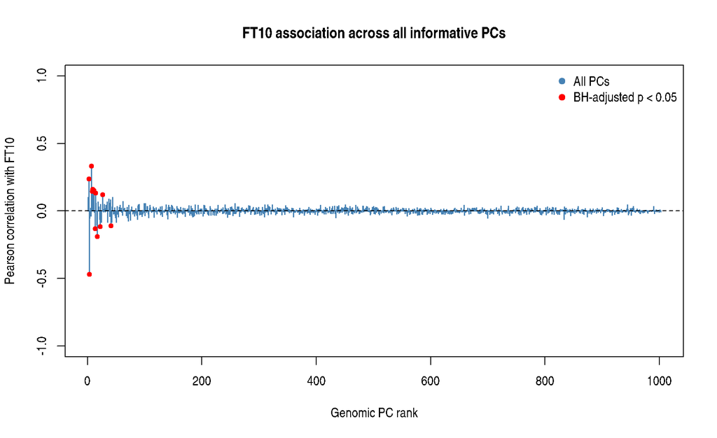

```r
# ------------------------------------------------
# 8. Plot correlations across all PCs
# ------------------------------------------------

plot(
  keep_pc,
  pearson_all,
  type = "h",
  lwd = 1.5,
  col = "steelblue",
  ylim = c(-1, 1),
  xlab = "Genomic PC rank",
  ylab = "Pearson correlation with FT10",
  main = "FT10 association across all informative PCs"
)

abline(h = 0, lty = 2)

# Highlight BH-significant associations
sig_all <- which(p_BH_all < 0.05)

points(
  keep_pc[sig_all],
  pearson_all[sig_all],
  pch = 19,
  col = "red",
  cex = 0.65
)

legend(
  "topright",
  legend = c("All PCs", "BH-adjusted p < 0.05"),
  col = c("steelblue", "red"),
  pch = 19,
  bty = "n"
)
```

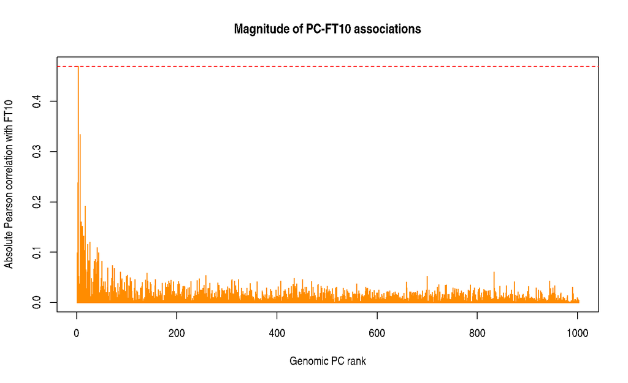

```r
# ------------------------------------------------
# 9. Examine the magnitude of correlations
# ------------------------------------------------

plot(
  keep_pc,
  abs(pearson_all),
  type = "h",
  lwd = 1.5,
  col = "darkorange",
  xlab = "Genomic PC rank",
  ylab = "Absolute Pearson correlation with FT10",
  main = "Magnitude of PC-FT10 associations"
)

abline(h = abs(pearson_all[which.max(abs(pearson_all))]),
       lty = 2, col = "red")
```

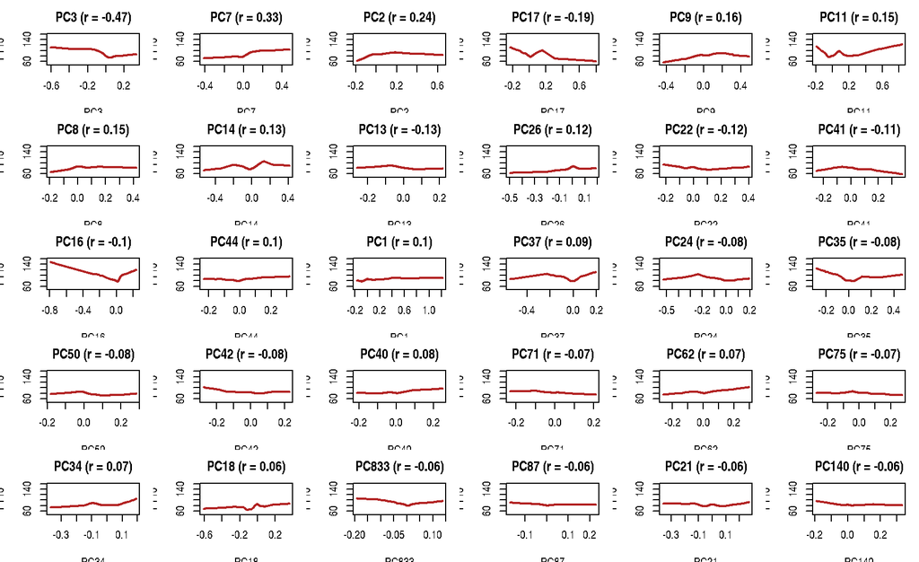

```r
# ------------------------------------------------
# 10. Examine the strongest 30 PCs individually
# ------------------------------------------------

top_pc_numbers <- keep_pc[top_order[
  1:min(30, N_PC_ALL)
]]

par(
  mfrow = c(5, 6),
  mar = c(3.5, 3.5, 2.5, 1)
)

for (j in top_pc_numbers) {

  plot(
    pcs_all[, match(j, keep_pc)],
    y_all,
    pch = 16,
    cex = 0.35,
    col = rgb(0.1, 0.35, 0.7, 0.4),
    xlab = paste0("PC", j),
    ylab = "FT10",
    main = paste0(
      "PC", j,
      " (r = ",
      round(pearson_all[match(j, keep_pc)], 2),
      ")"
    )
  )

  lines(
    lowess(
      pcs_all[, match(j, keep_pc)],
      y_all
    ),
    col = "firebrick",
    lwd = 2
  )
}
```

```r
par(mfrow = c(1, 1))


# ------------------------------------------------
# 11. Save complete results
# ------------------------------------------------

saveRDS(
  list(
    pcs_all = pcs_all,
    summary = pc_all_summary,
    top30 = top30,
    eigenvalue_tolerance = eig_tol
  ),
  "all_genomic_PC_associations.rds"
)

cat("\nALL-PC ANALYSIS COMPLETED.\n")
```

```
##
## ALL-PC ANALYSIS COMPLETED.
```

```r
# ============================================================
# REGRESSION USING THE PCs MOST STRONGLY ASSOCIATED WITH FT10
# ============================================================

# ------------------------------------------------------------
# 1. Rank all PCs by absolute Pearson correlation
# ------------------------------------------------------------

pc_order <- order(
  abs(pearson_all),
  decreasing = TRUE
)

# Identify top 100
top100_idx <- pc_order[1:100]

top100_table <- pc_all_summary[top100_idx, ]

top100_table <- top100_table[
  order(
    abs(top100_table$Pearson_FT10),
    decreasing = TRUE
  ),
]

cat("\nTOP 100 PCs ASSOCIATED WITH FT10:\n")
```

```
##
## TOP 100 PCs ASSOCIATED WITH FT10:
```

```r
print(top100_table, row.names = FALSE)
```

```
##   PC Eigenvalue Variance_pct Cumulative_variance_pct Pearson_FT10 Spearman_FT10
##    3 21.8818762   2.18381998                7.706348  -0.46956723 -0.4228689413
##    7 11.2055711   1.11832047               12.783801   0.33411032  0.3669065373
##    2 26.2590932   2.62066799                5.522528   0.23780398  0.3928124088
##   17  4.7372041   0.47277486               19.591438  -0.19087400 -0.1892667755
##    9  8.9109655   0.88931791               14.675076   0.15975256  0.1336144948
##   11  7.7295951   0.77141668               16.271386   0.15146828  0.1215393535
##    8 10.0396031   1.00195640               13.785758   0.14600879  0.2605009810
##   14  5.6983068   0.56869329               18.064507   0.13177561  0.2216664085
##   13  6.0817344   0.60695952               17.495814  -0.13086803 -0.2004245162
##   26  3.5941752   0.35870012               23.223125   0.11927182  0.1205893072
##   22  4.0720059   0.40638781               21.752896  -0.11518427 -0.1069259268
##   41  2.4192017   0.24143729               27.639725  -0.10837308 -0.1064456827
##   16  5.0993067   0.50891284               19.118663  -0.10271334  0.0369708540
##   44  2.3568173   0.23521131               28.349604   0.09886835  0.1201140045
##    1 29.0766368   2.90185996                2.901860   0.09884859  0.1457944831
##   37  2.6294984   0.26242499               26.645519   0.08592847  0.0892584883
##   24  3.7172492   0.37098295               22.502103  -0.08278434 -0.0692977921
##   35  2.8610273   0.28553167               26.116496  -0.08159707 -0.0934552757
##   50  2.1518468   0.21475517               29.673139  -0.08155796 -0.1623076339
##   42  2.3927177   0.23879418               27.878520  -0.08123186 -0.0735701049
##   40  2.4676481   0.24627227               27.398288   0.07949238  0.0571532562
##   71  1.7645245   0.17610025               33.697730  -0.07369659 -0.0506142425
##   62  1.8968501   0.18930640               32.064542   0.06801816  0.0027249909
##   75  1.7150723   0.17116490               34.390036  -0.06765963 -0.0613629236
##   34  2.8680861   0.28623614               25.830964   0.06604134  0.0305842112
##   18  4.5600323   0.45509304               20.046531   0.06446660  0.0170960062
##  833  0.3941392   0.03933525               96.642761  -0.06061587 -0.0482839269
##   87  1.5977167   0.15945276               36.365160  -0.06053297 -0.0679228865
##   21  4.1696603   0.41613377               21.346508  -0.06001932 -0.0273656026
##  140  1.2649542   0.12624294               43.866543  -0.05817253 -0.0527687466
##   15  5.4633348   0.54524300               18.609750   0.05710907  0.1570856553
##   38  2.5848119   0.25796526               26.903485   0.05571680  0.0001138857
##  101  1.4935935   0.14906123               38.524144   0.05367536 -0.0008274730
##  258  0.9730565   0.09711143               56.770661   0.05348530  0.0612152325
##  700  0.5664448   0.05653142               90.091523  -0.05199225 -0.0234231611
##   99  1.5159010   0.15128753               38.224872   0.05198933 -0.0129272324
##    4 14.9071952   1.48774403                9.194092  -0.05196604 -0.0860848287
##  107  1.4656738   0.14627483               39.408099  -0.04859072  0.0058585182
##  434  0.7864852   0.07849154               72.083369  -0.04807107 -0.0510555733
```

[output cut: 147 more lines]

```
##  2.443612e-01 9.995292e-01
##  2.482658e-01 9.995292e-01
##  2.504864e-01 9.995292e-01
##  2.541605e-01 9.995292e-01
##  2.567416e-01 9.995292e-01
##  2.586518e-01 9.995292e-01
##  2.594064e-01 9.995292e-01
##  2.606197e-01 9.995292e-01
##  2.621633e-01 9.995292e-01
##  2.723880e-01 9.995292e-01
##  2.765095e-01 9.995292e-01
##  2.768311e-01 9.995292e-01
##  2.836297e-01 9.995292e-01
##  2.856002e-01 9.995292e-01
##  2.899253e-01 9.995292e-01
```

```r
# ------------------------------------------------------------
# 2. Fit regression using the top 100 PCs
# ------------------------------------------------------------

top100_scores <- as.data.frame(
  pcs_all[, top100_idx, drop = FALSE]
)

fit_top100 <- lm(
  y_all ~ .,
  data = top100_scores
)

cat("\nREGRESSION USING TOP 100 PCs:\n")
```

```
##
## REGRESSION USING TOP 100 PCs:
```

```r
print(summary(fit_top100))
```

```
##
## Call:
## lm(formula = y_all ~ ., data = top100_scores)
##
## Residuals:
##      Min       1Q   Median       3Q      Max
## -29.9281  -4.8659  -0.1508   4.6456  27.8518
##
## Coefficients:
##             Estimate Std. Error t value Pr(>|t|)
## (Intercept)  83.5863     0.2657 314.563  < 2e-16 ***
## PC3         -56.9714     1.7990 -31.668  < 2e-16 ***
## PC7          56.6467     2.5140  22.533  < 2e-16 ***
## PC2          26.3379     1.6422  16.038  < 2e-16 ***
## PC17        -49.7723     3.8665 -12.873  < 2e-16 ***
## PC9          30.3730     2.8191  10.774  < 2e-16 ***
## PC11         30.9204     3.0269  10.215  < 2e-16 ***
## PC8          26.1530     2.6559   9.847  < 2e-16 ***
## PC14         31.3302     3.5254   8.887  < 2e-16 ***
## PC13        -30.1177     3.4124  -8.826  < 2e-16 ***
## PC26         35.7059     4.4389   8.044 2.73e-15 ***
## PC22        -32.3959     4.1704  -7.768 2.16e-14 ***
## PC41        -39.5446     5.4106  -7.309 5.94e-13 ***
## PC16        -25.8150     3.7267  -6.927 8.16e-12 ***
## PC44         36.5507     5.4817   6.668 4.52e-11 ***
## PC1          10.4040     1.5607   6.666 4.56e-11 ***
## PC37         30.0748     5.1897   5.795 9.43e-09 ***
## PC24        -24.3691     4.3648  -5.583 3.13e-08 ***
## PC35        -27.3788     4.9753  -5.503 4.87e-08 ***
## PC50        -31.5546     5.7368  -5.500 4.94e-08 ***
## PC42        -29.8045     5.4404  -5.478 5.57e-08 ***
## PC40         28.7201     5.3572   5.361 1.05e-07 ***
## PC71        -31.4873     6.3353  -4.970 8.00e-07 ***
## PC62         28.0292     6.1103   4.587 5.13e-06 ***
## PC75        -29.3218     6.4259  -4.563 5.74e-06 ***
## PC34         22.1320     4.9691   4.454 9.49e-06 ***
## PC18         17.1337     3.9409   4.348 1.53e-05 ***
## PC833       -54.7978    13.4046  -4.088 4.74e-05 ***
## PC87        -27.1796     6.6578  -4.082 4.85e-05 ***
## PC21        -16.6818     4.1212  -4.048 5.61e-05 ***
```

[output cut: 62 more lines]

```
## PC432        22.7750     9.4744   2.404 0.016424 *
## PC148        18.1285     7.5606   2.398 0.016699 *
## PC723        27.1974    11.3797   2.390 0.017053 *
## PC786        28.4927    12.1790   2.339 0.019528 *
## PC187       -18.4755     7.9653  -2.319 0.020591 *
## PC738       -26.7722    11.5500  -2.318 0.020676 *
## PC284        19.8472     8.6843   2.285 0.022519 *
## PC736        26.2454    11.5309   2.276 0.023074 *
## PC254       -19.1693     8.4978  -2.256 0.024323 *
## ---
## Signif. codes:  0 '***' 0.001 '**' 0.01 '*' 0.05 '.' 0.1 ' ' 1
##
## Residual standard error: 8.415 on 902 degrees of freedom
## Multiple R-squared:  0.8017, Adjusted R-squared:  0.7797
## F-statistic: 36.46 on 100 and 902 DF,  p-value: < 2.2e-16
```

```r
# ------------------------------------------------------------
# 3. Compare different numbers of selected PCs
# ------------------------------------------------------------

k_values <- c(1, 2, 5, 10, 20, 30, 50, 75, 100)

# Squared correlations in descending order
sorted_r2 <- sort(
  pearson_all^2,
  decreasing = TRUE
)

# Because PCs are orthogonal, this gives the
# in-sample OLS R-squared for the top k PCs.

r2_by_k <- vapply(
  k_values,
  function(k) sum(sorted_r2[1:k]),
  numeric(1)
)

model_comparison <- data.frame(
  Number_of_PCs = k_values,
  In_sample_R2 = round(r2_by_k, 4)
)

cat("\nIN-SAMPLE MODEL COMPARISON:\n")
```

```
##
## IN-SAMPLE MODEL COMPARISON:
```

```r
print(model_comparison)
```

```
##   Number_of_PCs In_sample_R2
## 1             1       0.2205
## 2             2       0.3321
## 3             5       0.4506
## 4            10       0.5436
## 5            20       0.6329
## 6            30       0.6767
## 7            50       0.7252
## 8            75       0.7686
## 9           100       0.8017
```

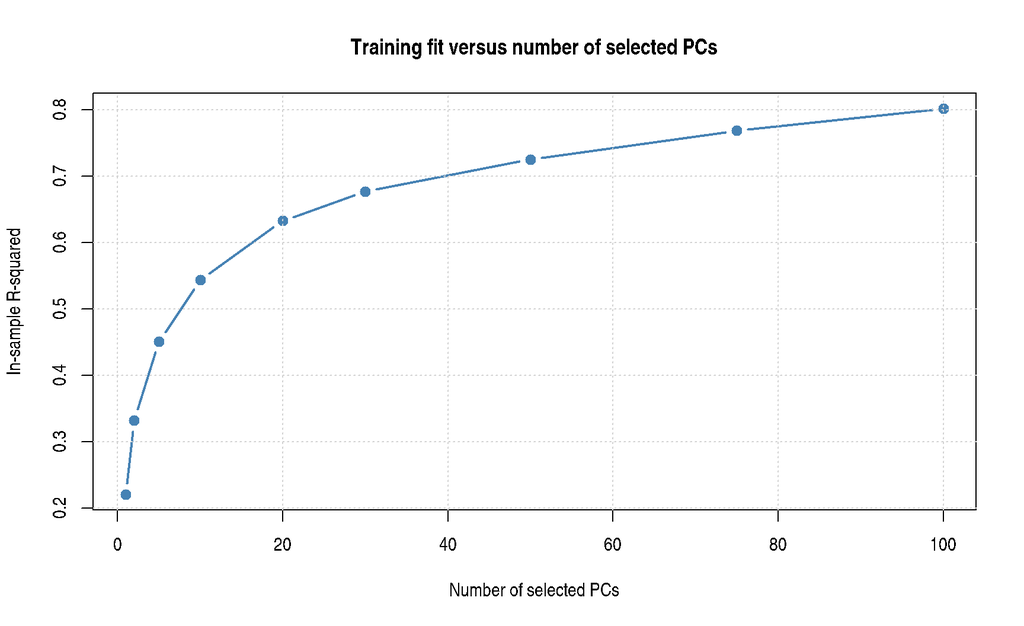

```r
# ------------------------------------------------------------
# 4. Plot the relationship between model size and R-squared
# ------------------------------------------------------------

plot(
  k_values,
  r2_by_k,
  type = "b",
  pch = 19,
  lwd = 2,
  col = "steelblue",
  xlab = "Number of selected PCs",
  ylab = "In-sample R-squared",
  main = "Training fit versus number of selected PCs"
)

grid()
```

```r
# ------------------------------------------------------------
# 5. Save results
# ------------------------------------------------------------

saveRDS(
  list(
    top100_table = top100_table,
    top100_model = fit_top100,
    model_comparison = model_comparison
  ),
  file = "top100_PC_FT10_regression.rds"
)

cat("\nTOP 100 PC REGRESSION ANALYSIS COMPLETED.\n")
```

```
##
## TOP 100 PC REGRESSION ANALYSIS COMPLETED.
```

```r
# ============================================================
# REGRESSION USING THE TOP 1000 PHENOTYPE-ASSOCIATED PCs
# ============================================================

stopifnot(N_PC_ALL >= 1000)

# Select 1000 PCs with largest absolute FT10 correlations
top1000_idx <- order(
  abs(pearson_all),
  decreasing = TRUE
)[1:1000]

top1000_scores <- as.data.frame(
  pcs_all[, top1000_idx, drop = FALSE]
)

# Fit OLS
fit_top1000 <- lm(
  y_all ~ .,
  data = top1000_scores
)

cat("Number of predictors:", 1000, "\n")
```

```
## Number of predictors: 1000
```

```r
cat("Residual degrees of freedom:",
    df.residual(fit_top1000), "\n")
```

```
## Residual degrees of freedom: 2
```

```r
cat("Training R-squared:",
    summary(fit_top1000)$r.squared, "\n")
```

```
## Training R-squared: 1
```

```r
cat("Adjusted R-squared:",
    summary(fit_top1000)$adj.r.squared, "\n")
```

```
## Adjusted R-squared: 0.9999989
```

```r
cat("Residual standard error:",
    summary(fit_top1000)$sigma, "\n")
```

```
## Residual standard error: 0.01914886
```

```r
# three ancestry clusters from the first five axes (unsupervised, no response); used for Mondrian conformal intervals
set.seed(2024)
grp <- kmeans(pcs5, centers = K_GROUPS, nstart = 25)$cluster
cat("ancestry cluster sizes:", paste(table(grp), collapse = " / "), "| mean FT10 by cluster:",
    paste(round(tapply(y_all, grp, mean), 1), collapse = " / "), "\n")
```

```
## ancestry cluster sizes: 128 / 855 / 20 | mean FT10 by cluster: 94.8 / 81.8 / 89.6
```

# 4. Replicating TARP: aggregation, PCA projection and randomized SVD

**Method (TARP, per the paper).** For each SNP compute its marginal correlation $r_j$ with the response; keep it with probability $q_j \propto |r_j|^{\delta}$, $\delta = \max\{0,(1+\log(p/n))/2\}$; compress the $p_\gamma$ survivors with a sparse random matrix $R$ (entries $\pm 1/\sqrt{2\psi}$ w.p. $\psi$, else 0) to $Z = XR'$ and fit the conjugate model $y = Z\theta + \varepsilon$ with prior $\theta\mid\sigma^2 \sim N(0,\sigma^2 I)$, giving $\mu_t = (I + Z'Z)^{-1}Z'y$ and a Student-t predictive distribution. A **single** projection is noisy, so the paper averages predictions over 100 projections with $m_n \sim U[2\log p,\,3n/4]$.

**Variants compared on the same screened SNPs.** (i) one projection, (ii) the 100-draw aggregation, (iii) exact PCA projection (RIS-PCR), and (iv) a randomized-SVD projection that uses TARP’s own sparse matrix as the sketch followed by `q` power iterations: `q = 0` is a data-adaptive rotation of one sketch, and `q -> infinity` recovers PCA, so `q` is a single knob between random projection and PCA.

```r
QS <- c(0, 1, 2, 4)
run_rep_si <- function(seed_i) {
  sp <- make_split(seed_i); tr <- sp$tr; te <- sp$te
  y_tr <- y_all[tr]; y_te <- y_all[te]; y_mean <- mean(y_tr); y_c <- y_tr - y_mean
  sc <- screen_set(tr, y_tr)                                  # RNG continues straight from the split
  X <- std_cols(G2[, sc$inc], tr, te); X_tr <- X$tr; X_te <- X$other; p_g <- ncol(X_tr)
  out <- list(seed = seed_i, baseline = mean((y_te - y_mean)^2), n_screened = p_g)
  tm <- system.time({ pca <- prcomp(X_tr, center = FALSE, scale. = FALSE, rank. = K_DIM) })[["elapsed"]]
  V_pca <- pca$rotation[, 1:K_DIM]
  out$PCA <- nig_mspe(X_tr %*% V_pca, X_te %*% V_pca, y_c, y_mean, y_te); out$t_PCA <- tm
  E_pca <- energy(X_tr, V_pca)
  Om <- tarp_omega(p_g, K_DIM); out$RP_single <- nig_mspe(X_tr %*% Om, X_te %*% Om, y_c, y_mean, y_te)
  tm <- system.time({ pa <- agg_tarp_pred(X_tr, X_te, y_c, y_mean, p, B = 100) })[["elapsed"]]
  out$RP_agg <- mean((y_te - pa)^2); out$t_RP_agg <- tm
  for (qq in QS) {
    tm <- system.time({ V <- rsvd_basis(X_tr, K_DIM, qq) })[["elapsed"]]
    out[[paste0("SI_q", qq)]] <- nig_mspe(X_tr %*% V, X_te %*% V, y_c, y_mean, y_te)
    out[[paste0("E_q", qq)]] <- energy(X_tr, V) / E_pca; out[[paste0("t_q", qq)]] <- tm
  }
  as.data.frame(out)
}
si <- run_seeds("si", run_rep_si, legacy = "si_replication_results.rds")
base_s <- setNames(si$baseline, si$seed)             # per-split mean-only MSPE, shared by every experiment
r2_of <- function(v, seeds = names(v)) 1 - v / base_s[seeds]
cat("splits:", nrow(si), "| SNPs surviving screening per split (mean):", round(mean(si$n_screened)), "\n")
```

```
## splits: 10 | SNPs surviving screening per split (mean): 8034
```

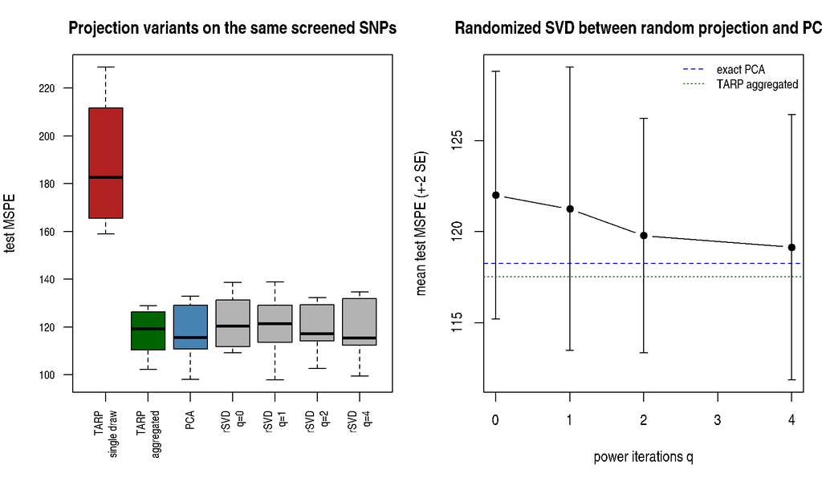

```r
cols <- c("RP_single", "RP_agg", "PCA", paste0("SI_q", QS))
lab  <- c("TARP\nsingle draw", "TARP\naggregated", "PCA", paste0("rSVD\nq=", QS))
par(mfrow = c(1, 2), mar = c(6, 4, 3, 1))
boxplot(si[, cols], names = lab, las = 2, cex.axis = 0.75, col = c("firebrick", "darkgreen", "steelblue", rep("grey70", length(QS))),
        ylab = "test MSPE", main = "Projection variants on the same screened SNPs")
abline(h = mean(si$baseline), lty = 3); text(1, mean(si$baseline), "mean-only predictor", pos = 3, cex = 0.7)
mu_q <- sapply(QS, function(q) mean(si[[paste0("SI_q", q)]])); se_q <- sapply(QS, function(q) sem(si[[paste0("SI_q", q)]]))
plot(QS, mu_q, type = "b", pch = 19, ylim = range(c(mu_q - 2 * se_q, mu_q + 2 * se_q, mean(si$PCA), mean(si$RP_agg))),
     xlab = "power iterations q", ylab = "mean test MSPE (+-2 SE)", main = "Randomized SVD between random projection and PCA")
arrows(QS, mu_q - 2 * se_q, QS, mu_q + 2 * se_q, angle = 90, code = 3, length = 0.04)
abline(h = mean(si$PCA), col = "blue", lty = 2); abline(h = mean(si$RP_agg), col = "darkgreen", lty = 3)
legend("topright", c("exact PCA", "TARP aggregated"), col = c("blue", "darkgreen"), lty = c(2, 3), bty = "n", cex = 0.8)
```

```r
par(mfrow = c(1, 1))
d_pca <- sapply(c("RP_single", "RP_agg", paste0("SI_q", QS)), function(m) si[[m]] - si$PCA)
knitr::kable(data.frame(Method = colnames(d_pca), Mean_MSPE = sapply(colnames(d_pca), function(m) mean(si[[m]])),
                        Diff_vs_PCA = colMeans(d_pca), SE = apply(d_pca, 2, sem), Beats_PCA = colSums(d_pca < 0)),
             digits = 2, row.names = FALSE, caption = "Paired differences against exact PCA (negative = better than PCA)")
```

Paired differences against exact PCA (negative = better than PCA)

| Method | Mean_MSPE | Diff_vs_PCA | SE | Beats_PCA |
| --- | --- | --- | --- | --- |
| RP_single | 188.05 | 69.79 | 5.03 | 0 |
| RP_agg | 117.53 | -0.72 | 1.60 | 6 |
| SI_q0 | 122.01 | 3.75 | 1.20 | 2 |
| SI_q1 | 121.26 | 3.00 | 0.96 | 2 |
| SI_q2 | 119.79 | 1.53 | 0.99 | 4 |
| SI_q4 | 119.14 | 0.89 | 0.49 | 3 |

```r
tab_cost <- data.frame(q = c(QS, Inf),
  Energy_vs_PCA = c(sapply(QS, function(q) mean(si[[paste0("E_q", q)]])), 1),
  Seconds = c(sapply(QS, function(q) mean(si[[paste0("t_q", q)]])), mean(si$t_PCA)))
knitr::kable(tab_cost, digits = 3, caption = "Share of exact-PCA captured energy and mean wall time (single-threaded BLAS)")
```

Share of exact-PCA captured energy and mean wall time (single-threaded BLAS)

| q | Energy_vs_PCA | Seconds |
| --- | --- | --- |
| 0 | 0.917 | 1.206 |
| 1 | 0.977 | 2.387 |
| 2 | 0.990 | 3.645 |
| 4 | 0.997 | 6.148 |
| Inf | 1.000 | 14.335 |

```r
cat("Aggregated TARP: median wall time per split", round(median(si$t_RP_agg)), "seconds (the mean is distorted by any pause of the machine).\n")
```

```
## Aggregated TARP: median wall time per split 182 seconds (the mean is distorted by any pause of the machine).
```

**Scaling benchmark.** Wall time for exact SVD (`prcomp`), exact PCA through the n x n Gram matrix, randomized SVD (q = 2) and the paper’s 100-draw aggregation (extrapolated from 5 draws) as the number of screened SNPs grows. Unless `RUN_SCALING <- TRUE`, the values recorded in the original run (single-threaded, same laptop) are shown.

```r
scaling <- data.frame(p_screened = c(5000, 20000, 50000, 100000),
  exact_svd = c(8.953, 35.725, 91.573, 189.92), exact_gram = c(2.822, 11.013, 23.434, 47.048),
  rsvd_q2 = c(2.23, 9.163, 24.314, 47.25), tarp_agg100_extrap = c(86.96, 366.92, 908.38, 1796.46),
  rsvd_energy_vs_exact = c(0.9975744, 0.9951787, 0.9925784, 0.9891172))
if (RUN_SCALING) {
  sp1 <- make_split(1); gw <- big_univLinReg(G2, y.train = y_all[sp1$tr], ind.train = sp1$tr, ncores = N_CORES)
  ord <- order(abs(gw$estim / gw$std.err), decreasing = TRUE); ord[is.na(ord)] <- length(ord)
  scaling <- do.call(rbind, lapply(scaling$p_screened, function(K) {
    X <- G2[sp1$tr, ord[1:K]]; cs <- apply(X, 2, sd); cs[cs == 0] <- 1; X <- scale(X, center = TRUE, scale = cs)
    t_svd <- system.time(prcomp(X, center = FALSE, scale. = FALSE, rank. = K_DIM))[["elapsed"]]
    t_gram <- system.time(Vg <- gram_pca_basis(X, K_DIM))[["elapsed"]]
    t_rsvd <- system.time(Vr <- rsvd_basis(X, K_DIM, 2))[["elapsed"]]
    t_agg5 <- system.time(for (b in 1:5) { Zb <- X %*% tarp_omega(K, 315) })[["elapsed"]]
    data.frame(p_screened = K, exact_svd = t_svd, exact_gram = t_gram, rsvd_q2 = t_rsvd,
               tarp_agg100_extrap = t_agg5 * 20, rsvd_energy_vs_exact = energy(X, Vr) / energy(X, Vg))
  }))
}
knitr::kable(scaling, digits = 3, caption = "Seconds to obtain 100 projection directions (and rSVD energy relative to exact)")
```

Seconds to obtain 100 projection directions (and rSVD energy relative to exact)

| p_screened | exact_svd | exact_gram | rsvd_q2 | tarp_agg100_extrap | rsvd_energy_vs_exact |
| --- | --- | --- | --- | --- | --- |
| 5e+03 | 8.953 | 2.822 | 2.230 | 86.96 | 0.998 |
| 2e+04 | 35.725 | 11.013 | 9.163 | 366.92 | 0.995 |
| 5e+04 | 91.573 | 23.434 | 24.314 | 908.38 | 0.993 |
| 1e+05 | 189.920 | 47.048 | 47.250 | 1796.46 | 0.989 |

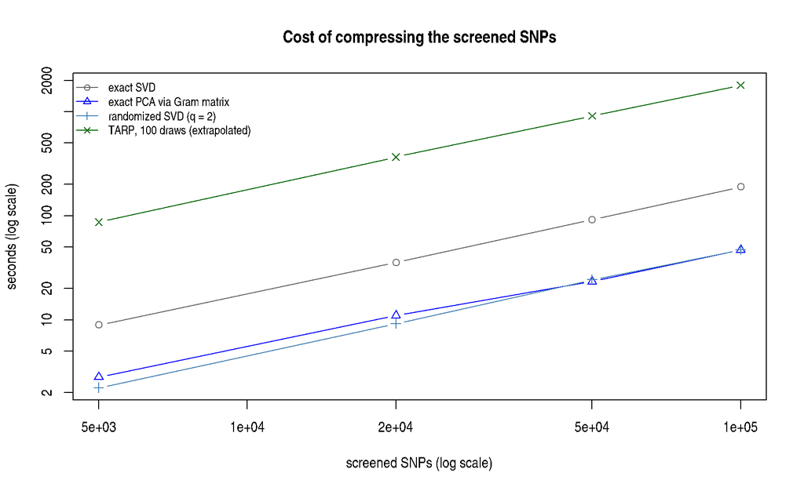

```r
matplot(scaling$p_screened, scaling[, c("exact_svd", "exact_gram", "rsvd_q2", "tarp_agg100_extrap")], type = "b", pch = 1:4,
        lty = 1, log = "xy", col = c("grey40", "blue", "steelblue", "darkgreen"), xlab = "screened SNPs (log scale)",
        ylab = "seconds (log scale)", main = "Cost of compressing the screened SNPs")
legend("topleft", c("exact SVD", "exact PCA via Gram matrix", "randomized SVD (q = 2)", "TARP, 100 draws (extrapolated)"),
       col = c("grey40", "blue", "steelblue", "darkgreen"), pch = 1:4, lty = 1, bty = "n", cex = 0.8)
```

```r
d_agg <- si$RP_agg - si$PCA
cat(sprintf("- **A single random projection is unreliable**: mean MSPE %.1f, against %.1f for the 100-draw aggregation and %.1f for exact PCA (mean-only predictor: %.1f).\n",
            mean(si$RP_single), mean(si$RP_agg), mean(si$PCA), mean(si$baseline)))
```

- **A single random projection is unreliable**: mean MSPE 188.1, against 117.5 for the 100-draw aggregation and 118.3 for exact PCA (mean-only predictor: 334.8).

```r
cat(sprintf("- **Aggregated TARP matches exact PCA** (difference %.1f, SE %.1f; aggregation wins in %d of %d splits), reproducing the paper's statement that RIS-RP and RIS-PCR are comparable.\n",
            mean(d_agg), sem(d_agg), sum(d_agg < 0), nrow(si)))
```

- **Aggregated TARP matches exact PCA** (difference -0.7, SE 1.6; aggregation wins in 6 of 10 splits), reproducing the paper’s statement that RIS-RP and RIS-PCR are comparable.

```r
cat(sprintf("- **Randomized SVD closes the gap to PCA as q grows**: mean difference from PCA %.1f at q = 0 and %.1f at q = 2, recovering %.1f%% of the exact captured energy at q = 2.\n",
            mean(si$SI_q0 - si$PCA), mean(si$SI_q2 - si$PCA), 100 * mean(si$E_q2)))
```

- **Randomized SVD closes the gap to PCA as q grows**: mean difference from PCA 3.7 at q = 0 and 1.5 at q = 2, recovering 99.0% of the exact captured energy at q = 2.

```r
cat(sprintf("- **Cost**: at 100,000 screened SNPs, randomized SVD (q = 2) takes %.0f s versus about %.0f s for the 100-draw aggregation (%.0fx cheaper) and %.0f s for exact SVD; exact PCA through the Gram matrix is just as fast as randomized SVD (%.0f s), so the saving is relative to the aggregation, not to PCA.\n",
            scaling$rsvd_q2[4], scaling$tarp_agg100_extrap[4], scaling$tarp_agg100_extrap[4] / scaling$rsvd_q2[4],
            scaling$exact_svd[4], scaling$exact_gram[4]))
```

- **Cost**: at 100,000 screened SNPs, randomized SVD (q = 2) takes 47 s versus about 1796 s for the 100-draw aggregation (38x cheaper) and 190 s for exact SVD; exact PCA through the Gram matrix is just as fast as randomized SVD (47 s), so the saving is relative to the aggregation, not to PCA.

# 5. Screening and variable selection: SIS, randomized SIS, iterated SIS and structure-adjusted SIS

| Screen | Rule |
| --- | --- |
| `SIS` (d = n/log n, 2000, or the RIS survivor count) | deterministic top-$d$ by absolute marginal correlation |
| `RIS` | Bernoulli($q_j$) with $q_j$ proportional to (absolute marginal correlation)$^{\delta}$ (TARP step 1) |
| `ISIS` | iterated SIS: select, fit a lasso, take residuals, re-screen (3 rounds) |
| `SISadj` | SIS on the response after removing the first five genomic (ancestry) axes |

After screening, the survivors are modeled with the lasso, ridge or elastic net (`glmnet`), the standard “SIS + penalized regression” recipe, and compared with TARP’s projections and with the dense GBLUP baseline.

```r
HAS_GLMNET <- requireNamespace("glmnet", quietly = TRUE)
if (!HAS_GLMNET) message("glmnet is not installed: lasso/ridge-after-screening rows are skipped. ",
                         "Install once with: micromamba install -c conda-forge r-glmnet")
screen_scores <- function(tr_rows, y_vec) {              # signed t-statistic of every SNP against y_vec (training rows only)
  gw <- big_univLinReg(G2, y.train = y_vec, ind.train = tr_rows, ncores = N_CORES)
  tt <- gw$estim / gw$std.err; tt[is.na(tt)] <- 0; tt
}
sis_top <- function(score, d) order(abs(score), decreasing = TRUE)[1:d]
adjust_response <- function(tr_rows, y_vec) resid(lm(y_vec ~ pcs5[tr_rows, , drop = FALSE]))   # remove ancestry axes
isis_set <- function(tr_rows, y_vec, d_total, n_iter = 3) {
  d_step <- ceiling(d_total / n_iter); sel <- integer(0); y_c <- y_vec - mean(y_vec); y_res <- y_c
  for (it in seq_len(n_iter)) {
    tt <- screen_scores(tr_rows, y_res); tt[sel] <- 0
    sel <- c(sel, order(abs(tt), decreasing = TRUE)[1:d_step])
    if (it < n_iter) {
      Xs <- scale(G2[tr_rows, sel, drop = FALSE]); Xs[is.na(Xs)] <- 0
      fit <- if (HAS_GLMNET) {
        cv <- glmnet::cv.glmnet(Xs, y_c, alpha = 1, nfolds = 5); as.numeric(predict(cv, Xs, s = "lambda.min"))
      } else {
        as.numeric(Xs %*% solve(crossprod(Xs) + 0.1 * length(tr_rows) * diag(ncol(Xs)), crossprod(Xs, y_c)))
      }
      y_res <- y_c - fit
    }
  }
  sel
}
# penalized fit on a screened set; lambda by glmnet's internal 10-fold CV (in-sample, so subject to the screening
# bias discussed in Section 6, but the test MSPE below is untouched by it); optionally ancestry axes unpenalized
pen_fit <- function(sel, tr, te, y_tr, y_te, alpha, pcs_cov = FALSE) {
  if (!HAS_GLMNET) return(c(mspe = NA_real_, nz = NA_real_))
  X <- std_cols(G2[, sel, drop = FALSE], tr, te); keep <- apply(X$tr, 2, sd) > 1e-8
  x_tr <- X$tr[, keep, drop = FALSE]; x_te <- X$other[, keep, drop = FALSE]; pf <- rep(1, ncol(x_tr))
  if (pcs_cov) { x_tr <- cbind(pcs5[tr, ], x_tr); x_te <- cbind(pcs5[te, ], x_te); pf <- c(rep(0, ncol(pcs5)), pf) }
  cv <- glmnet::cv.glmnet(x_tr, y_tr, alpha = alpha, nfolds = 10, penalty.factor = pf)
  pr <- as.numeric(predict(cv, x_te, s = "lambda.min"))
  c(mspe = mean((y_te - pr)^2), nz = sum(as.numeric(coef(cv, s = "lambda.min"))[-1] != 0))
}
```

## 5.1 Prediction after screening: SIS, RIS, ISIS and structure-adjusted SIS with penalized regression

```r
run_rep_sis <- function(seed_i) {
  sp <- make_split(seed_i); tr <- sp$tr; te <- sp$te
  y_tr <- y_all[tr]; y_te <- y_all[te]; ym <- mean(y_tr)
  sc <- screen_set(tr, y_tr)                                 # RIS survivors
  tt <- screen_scores(tr, y_tr)
  d1 <- floor(length(tr) / log(length(tr))); d2 <- 2000; dR <- length(sc$inc)
  S <- list(SIS1 = sis_top(tt, d1), SIS2 = sis_top(tt, d2), SISR = sis_top(tt, dR), RIS = sc$inc,
            ADJ2 = sis_top(screen_scores(tr, adjust_response(tr, y_tr)), d2), ISIS2 = isis_set(tr, y_tr, d2))
  f <- function(sel, alpha, pc = FALSE) pen_fit(sel, tr, te, y_tr, y_te, alpha, pc)
  r1 <- f(S$SIS1, 1); r2 <- f(S$SIS2, 1); r3 <- f(S$SIS2, 0); r4 <- f(S$SISR, 0); r5 <- f(S$RIS, 0)
  r6 <- f(S$ISIS2, 1); r7 <- f(S$ADJ2, 1, TRUE); r8 <- f(S$ADJ2, 0, TRUE)
  data.frame(seed = seed_i, baseline = mean((y_te - ym)^2), d1 = d1, dR = dR,
    SIS_d1_lasso = unname(r1["mspe"]), SIS_2000_lasso = unname(r2["mspe"]), SIS_2000_ridge = unname(r3["mspe"]),
    SIS_RISsize_ridge = unname(r4["mspe"]), RIS_ridge = unname(r5["mspe"]), ISIS_2000_lasso = unname(r6["mspe"]),
    SISadj_2000_lasso_pc = unname(r7["mspe"]), SISadj_2000_ridge_pc = unname(r8["mspe"]),
    nz_SIS_d1_lasso = unname(r1["nz"]), nz_SIS_2000_lasso = unname(r2["nz"]), nz_ISIS_2000_lasso = unname(r6["nz"]),
    nz_SISadj_2000_lasso_pc = unname(r7["nz"]),
    GBLUP = mean((y_te - gblup_fit(tr, te, y_tr)$pred)^2))
}
sis_res <- run_seeds("sis", run_rep_sis)
```

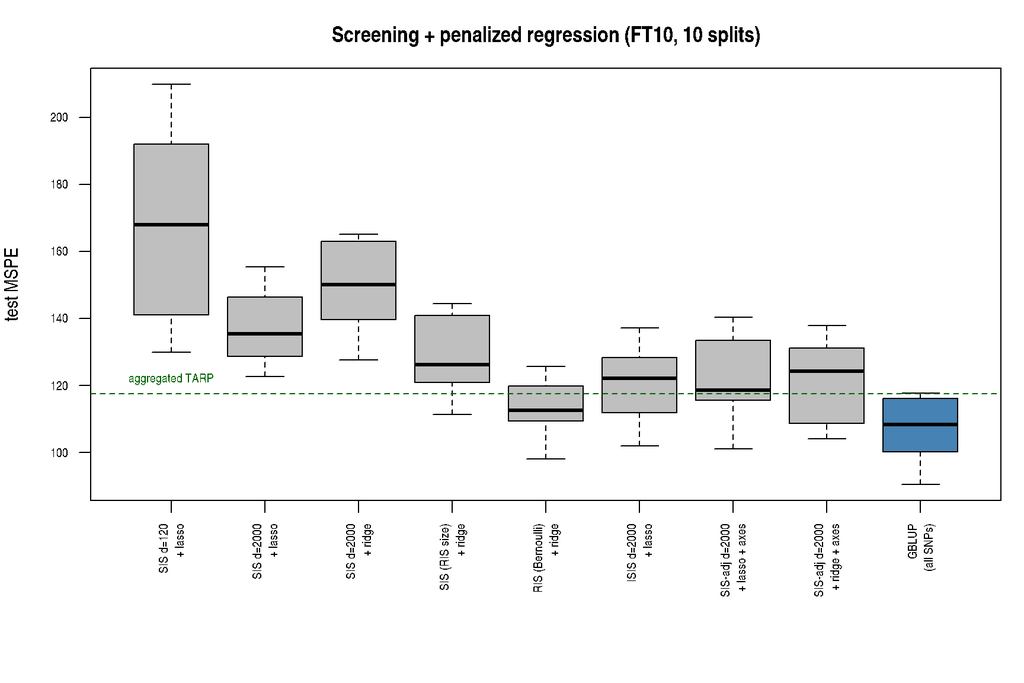

```r
mcols <- c("SIS_d1_lasso", "SIS_2000_lasso", "SIS_2000_ridge", "SIS_RISsize_ridge", "RIS_ridge", "ISIS_2000_lasso",
           "SISadj_2000_lasso_pc", "SISadj_2000_ridge_pc", "GBLUP")
mlab <- c("SIS d=120\n+ lasso", "SIS d=2000\n+ lasso", "SIS d=2000\n+ ridge", "SIS (RIS size)\n+ ridge", "RIS (Bernoulli)\n+ ridge",
          "ISIS d=2000\n+ lasso", "SIS-adj d=2000\n+ lasso + axes", "SIS-adj d=2000\n+ ridge + axes", "GBLUP\n(all SNPs)")
ok <- sapply(mcols, function(m) any(!is.na(sis_res[[m]])))
par(mar = c(8, 4, 3, 1))
boxplot(sis_res[, mcols[ok]], names = mlab[ok], las = 2, cex.axis = 0.7, ylab = "test MSPE",
        col = c(rep("grey75", sum(ok) - 1), "steelblue"), main = "Screening + penalized regression (FT10, 10 splits)")
abline(h = mean(si$RP_agg), lty = 2, col = "darkgreen"); text(1, mean(si$RP_agg), "aggregated TARP", col = "darkgreen", pos = 3, cex = 0.7)
```

```r
par(mar = c(5, 4, 4, 2))
dg <- lapply(mcols[ok][-sum(ok)], function(m) sis_res[[m]] - sis_res$GBLUP)
names(dg) <- mcols[ok][-sum(ok)]
tab_sis <- data.frame(Method = names(dg),
  Mean_MSPE = sapply(names(dg), function(m) mean(sis_res[[m]])),
  R2 = sapply(names(dg), function(m) mean(1 - sis_res[[m]] / sis_res$baseline)),
  Diff_vs_GBLUP = sapply(dg, mean), SE = sapply(dg, sem), Beats_GBLUP = sapply(dg, function(x) sum(x < 0)))
knitr::kable(tab_sis, digits = 3, row.names = FALSE, caption = "Paired differences against full-SNP GBLUP (positive = worse than GBLUP)")
```

Paired differences against full-SNP GBLUP (positive = worse than GBLUP)

| Method | Mean_MSPE | R2 | Diff_vs_GBLUP | SE | Beats_GBLUP |
| --- | --- | --- | --- | --- | --- |
| SIS_d1_lasso | 168.977 | 0.493 | 61.734 | 7.517 | 0 |
| SIS_2000_lasso | 137.479 | 0.587 | 30.236 | 2.806 | 0 |
| SIS_2000_ridge | 149.023 | 0.553 | 41.779 | 3.188 | 0 |
| SIS_RISsize_ridge | 128.248 | 0.615 | 21.005 | 2.153 | 0 |
| RIS_ridge | 113.035 | 0.660 | 5.792 | 1.482 | 1 |
| ISIS_2000_lasso | 119.624 | 0.640 | 12.381 | 1.859 | 0 |
| SISadj_2000_lasso_pc | 122.241 | 0.633 | 14.997 | 3.749 | 0 |
| SISadj_2000_ridge_pc | 121.505 | 0.635 | 14.261 | 2.585 | 0 |

```r
nzt <- data.frame(Model = c("SIS d=120 + lasso", "SIS d=2000 + lasso", "ISIS d=2000 + lasso", "SIS-adj + lasso + axes"),
                  Mean_nonzero_SNPs = c(mean(sis_res$nz_SIS_d1_lasso), mean(sis_res$nz_SIS_2000_lasso),
                                         mean(sis_res$nz_ISIS_2000_lasso), mean(sis_res$nz_SISadj_2000_lasso_pc)))
knitr::kable(nzt, digits = 1, row.names = FALSE, caption = "SNPs retained by the lasso after screening")
```

SNPs retained by the lasso after screening

| Model | Mean_nonzero_SNPs |
| --- | --- |
| SIS d=120 + lasso | 27.9 |
| SIS d=2000 + lasso | 88.2 |
| ISIS d=2000 + lasso | 415.0 |
| SIS-adj + lasso + axes | 158.8 |

## 5.2 What the screens select: genomic-structure tagging, marker redundancy and genomic concentration

Marginal screening ranks SNPs individually, but selected marker sets may differ substantially in the genomic information they represent. We examine four properties: (i) the mean absolute correlation of selected SNPs with the first genomic principal component (PC1), (ii) the average SNP-wise R-squared explained by the first ten genomic principal components (PC1–PC10), (iii) the mean pairwise absolute genotype correlation among selected SNPs, and (iv) the number of distinct 50-kb genomic regions represented by the selected markers. The PC-based diagnostics measure the association of selected markers with major axes of genomic variation. Pairwise genotype correlations provide a measure of marker redundancy, although they may reflect both local linkage disequilibrium and population structure. The positional grouping is a physical clustering heuristic: SNPs on the same chromosome separated by no more than 50 kb are grouped together. These regions are not formally identified LD blocks.

```r
# ================================================================
# SECTION 5.2: WHAT DO THE SELECTED SNP SETS ACTUALLY REPRESENT?
#
# Diagnostics:
# 1. Mean |cor(SNP, PC1)|
# 2. Mean SNP-wise R2 explained by PC1-PC10 jointly
# 3. Mean pairwise |SNP-SNP correlation| (LD redundancy diagnostic)
# 4. Number of 50-kb-gap genomic regions
#
# Each selected set is compared with size-matched random SNP sets.
# ================================================================

N_RANDOM_REF <- 5L
N_LD_SAMPLE <- 200L
REGION_GAP_BP <- 50000L

# ------------------------------------------------
# A. Recover the selected sets from the 10 splits
# ------------------------------------------------

sel_cache <- file.path("cache", "sel_sets.rds")

if (USE_CACHE && file.exists(sel_cache)) {

  sel_sets <- readRDS(sel_cache)

} else {

  sel_sets <- lapply(seq_len(N_REPS), function(s) {

    sp <- make_split(s)
    tr <- sp$tr
    y_tr <- y_all[tr]

    sc <- screen_set(tr, y_tr)
    tt <- screen_scores(tr, y_tr)

    list(
      SIS_d1 = sis_top(
        tt,
        floor(length(tr) / log(length(tr)))
      ),

      SIS_2000 = sis_top(tt, 2000),

      RIS = sc$inc,

      SISadj_2000 = sis_top(
        screen_scores(
          tr,
          adjust_response(tr, y_tr)
        ),
        2000
      )
    )
  })

  saveRDS(sel_sets, sel_cache)
}

# ------------------------------------------------
# B. Construct the first 10 genomic PC axes
# ------------------------------------------------

# Use the already-computed full genomic eigendecomposition.
# This is a genotype-only descriptive diagnostic.

N_STRUCT_PC <- 10L

pcs10 <- sweep(
  eK$vectors[, 1:N_STRUCT_PC, drop = FALSE],
  2,
  sqrt(eK$values[1:N_STRUCT_PC]),
  "*"
)

# Standardize PC scores so that correlations can be
# calculated directly using cross-products.

pcs10_z <- scale(pcs10)

n_obs <- nrow(G2)
p_obs <- ncol(G2)

stopifnot(nrow(pcs10_z) == n_obs)
stopifnot(nrow(map) == p_obs)

# Preserve these variables because the following LD and
# Manhattan chunks use chr_int and pos_bp.

chr_int <- suppressWarnings(as.integer(map$chromosome))
chr_label <- as.character(map$chromosome)
pos_bp <- as.numeric(map$physical.pos)

# ------------------------------------------------
# C. Function to calculate diagnostics for one SNP set
# ------------------------------------------------

sel_metrics <- function(sel) {

  sel <- unique(as.integer(sel))

  sel <- sel[
    !is.na(sel) &
      sel >= 1 &
      sel <= p_obs
  ]

  if (length(sel) == 0) {
    return(c(
      anc_cor = NA_real_,
      structure_r2_10 = NA_real_,
      pairwise_cor = NA_real_,
      loci = NA_real_,
      size = 0,
      variable_size = 0
    ))
  }

  # Extract selected genotypes.
  X_raw <- as.matrix(
    G2[, sel, drop = FALSE]
  )

  # Remove SNPs with zero or undefined variance.
  snp_sd <- apply(X_raw, 2, sd)

  keep <- is.finite(snp_sd) & snp_sd > 0

  if (!any(keep)) {
    return(c(
      anc_cor = NA_real_,
      structure_r2_10 = NA_real_,
      pairwise_cor = NA_real_,
      loci = NA_real_,
      size = length(sel),
      variable_size = 0
    ))
  }

  # Standardize each selected SNP across accessions.
  Xs <- scale(
    X_raw[, keep, drop = FALSE]
  )

  rm(X_raw)

  # ------------------------------------------------
  # Diagnostic 1 and 2:
  # Association with the first 10 genomic PCs
  # ------------------------------------------------

  # Because both matrices have centred, unit-SD columns,
  # these cross-products are sample correlations.

  cor_pc <- crossprod(
    pcs10_z,
    Xs
  ) / (n_obs - 1)

  # Diagnostic 1:
  # Mean absolute correlation with PC1.
  anc_cor <- mean(
    abs(cor_pc[1, ]),
    na.rm = TRUE
  )

  # Diagnostic 2:
  # For SNP j, its R2 from regression on PC1-PC10 is
  # the sum of squared correlations with those axes,
  # since the PC scores are mutually orthogonal.

  snp_r2_10 <- pmin(
    1,
    colSums(cor_pc^2)
  )

  structure_r2_10 <- mean(
    snp_r2_10,
    na.rm = TRUE
  )

  # ------------------------------------------------
  # Diagnostic 3:
  # Mean pairwise absolute correlation among selected SNPs
  # ------------------------------------------------

  m_ld <- min(
    ncol(Xs),
    N_LD_SAMPLE
  )

  if (m_ld >= 2) {

    # Use a fixed maximum sample size to keep computation feasible.
    ld_idx <- sample.int(
      ncol(Xs),
      m_ld
    )

    C_ld <- cor(
      Xs[, ld_idx, drop = FALSE]
    )

    pairwise_cor <- mean(
      abs(C_ld[upper.tri(C_ld)]),
      na.rm = TRUE
    )

  } else {

    pairwise_cor <- NA_real_
  }

  # ------------------------------------------------
  # Diagnostic 4:
  # Number of 50-kb-gap genomic regions
  # ------------------------------------------------

  chr_sel <- chr_label[sel]
  pos_sel <- pos_bp[sel]

  map_ok <- !is.na(chr_sel) &
    is.finite(pos_sel)

  chr_sel <- chr_sel[map_ok]
  pos_sel <- pos_sel[map_ok]

  if (length(pos_sel) == 0) {

    loci <- NA_real_

  } else {

    ord <- order(chr_sel, pos_sel)

    ch <- chr_sel[ord]
    ps <- pos_sel[ord]

    if (length(ps) == 1) {

      loci <- 1L

    } else {

      # A new region starts when:
      # (i) the chromosome changes, or
      # (ii) the gap from the previous selected SNP exceeds 50 kb.

      starts_region <- c(
        TRUE,
        ch[-1] != ch[-length(ch)] |
          diff(ps) > REGION_GAP_BP
      )

      loci <- sum(starts_region)
    }
  }

  c(
    anc_cor = anc_cor,
    structure_r2_10 = structure_r2_10,
    pairwise_cor = pairwise_cor,
    loci = loci,
    size = length(sel),
    variable_size = ncol(Xs)
  )
}


# ------------------------------------------------
# D. Calculate diagnostics for selected and random sets
# ------------------------------------------------

set.seed(20261102)

selected_rows <- list()
random_rows <- list()

i_selected <- 0L
i_random <- 0L

for (s in seq_along(sel_sets)) {

  for (m in names(sel_sets[[s]])) {

    sel <- unique(sel_sets[[s]][[m]])

    # Diagnostics for the actual selected set.
    i_selected <- i_selected + 1L

    selected_rows[[i_selected]] <- data.frame(
      seed = s,
      set = m,
      t(sel_metrics(sel))
    )

    # Generate five random SNP sets of exactly the
    # same nominal size as the corresponding selected set.

    for (b in seq_len(N_RANDOM_REF)) {

      rand_sel <- sample.int(
        p_obs,
        size = length(sel),
        replace = FALSE
      )

      i_random <- i_random + 1L

      random_rows[[i_random]] <- data.frame(
        seed = s,
        set = m,
        reference = b,
        t(sel_metrics(rand_sel))
      )
    }
  }
}

diag_selected <- do.call(
  rbind,
  selected_rows
)

diag_random <- do.call(
  rbind,
  random_rows
)


# ------------------------------------------------
# E. Average the random references within each split
# ------------------------------------------------

random_by_split <- aggregate(
  cbind(
    anc_cor,
    structure_r2_10,
    pairwise_cor,
    loci,
    size,
    variable_size
  ) ~ seed + set,

  data = diag_random,

  FUN = function(z) mean(z, na.rm = TRUE)
)


# ------------------------------------------------
# F. Match every selected set with its random reference
# ------------------------------------------------

diag_compare <- merge(
  diag_selected,
  random_by_split,
  by = c("seed", "set"),
  suffixes = c("_selected", "_random")
)


# ------------------------------------------------
# G. Summarize selected-versus-random differences
# ------------------------------------------------

mean_diff <- function(a, b) {
  mean(a - b, na.rm = TRUE)
}

se_diff <- function(a, b) {

  z <- a - b

  sd(z, na.rm = TRUE) /
    sqrt(sum(is.finite(z)))
}

summarise_method <- function(method_name) {

  d <- diag_compare[
    diag_compare$set == method_name,
  ]

  region_density_selected <-
    1000 * d$loci_selected / d$size_selected

  region_density_random <-
    1000 * d$loci_random / d$size_random

  data.frame(

    set = method_name,

    mean_selected_size =
      mean(d$size_selected),

    PC1_mean_abs_r_selected =
      mean(d$anc_cor_selected),

    PC1_mean_abs_r_random =
      mean(d$anc_cor_random),

    PC1_mean_abs_r_diff =
      mean_diff(d$anc_cor_selected, d$anc_cor_random),

    PC1_mean_abs_r_diff_SE =
      se_diff(d$anc_cor_selected, d$anc_cor_random),

    PC1_10_mean_R2_selected =
      mean(d$structure_r2_10_selected),

    PC1_10_mean_R2_random =
      mean(d$structure_r2_10_random),

    PC1_10_mean_R2_diff =
      mean_diff(
        d$structure_r2_10_selected,
        d$structure_r2_10_random
      ),

    PC1_10_mean_R2_diff_SE =
      se_diff(
        d$structure_r2_10_selected,
        d$structure_r2_10_random
      ),

    pairwise_abs_r_selected =
      mean(d$pairwise_cor_selected),

    pairwise_abs_r_random =
      mean(d$pairwise_cor_random),

    pairwise_abs_r_diff =
      mean_diff(
        d$pairwise_cor_selected,
        d$pairwise_cor_random
      ),

    pairwise_abs_r_diff_SE =
      se_diff(
        d$pairwise_cor_selected,
        d$pairwise_cor_random
      ),

    regions_per_1000_selected =
      mean(region_density_selected, na.rm = TRUE),

    regions_per_1000_random =
      mean(region_density_random, na.rm = TRUE),

    regions_per_1000_diff =
      mean_diff(
        region_density_selected,
        region_density_random
      ),

    regions_per_1000_diff_SE =
      se_diff(
        region_density_selected,
        region_density_random
      )
  )
}

diag_summary <- do.call(
  rbind,
  lapply(
    unique(diag_compare$set),
    summarise_method
  )
)


# ------------------------------------------------
# H. Preserve agg_diag for downstream report compatibility
# ------------------------------------------------

agg_diag <- aggregate(
  cbind(
    anc_cor,
    structure_r2_10,
    pairwise_cor,
    loci,
    size
  ) ~ set,

  data = diag_selected,

  FUN = mean
)

# Matched random reference for SIS with d = 2000.
rand_anc <- diag_summary$PC1_mean_abs_r_random[
  diag_summary$set == "SIS_2000"
]


# ------------------------------------------------
# I. Display the comparison table
# ------------------------------------------------

knitr::kable(
  diag_summary,
  digits = 3,
  row.names = FALSE,
  caption = paste(
    "Selected SNP sets versus five size-matched random references;",
    "means over 10 splits."
  )
)
```

Selected SNP sets versus five size-matched random references; means over 10 splits.

| set | mean_selected_size | PC1_mean_abs_r_selected | PC1_mean_abs_r_random | PC1_mean_abs_r_diff | PC1_mean_abs_r_diff_SE | PC1_10_mean_R2_selected | PC1_10_mean_R2_random | PC1_10_mean_R2_diff | PC1_10_mean_R2_diff_SE | pairwise_abs_r_selected | pairwise_abs_r_random | pairwise_abs_r_diff | pairwise_abs_r_diff_SE | regions_per_1000_selected | regions_per_1000_random | regions_per_1000_diff | regions_per_1000_diff_SE |
| --- | --- | --- | --- | --- | --- | --- | --- | --- | --- | --- | --- | --- | --- | --- | --- | --- | --- |
| RIS | 8034.4 | 0.089 | 0.107 | -0.018 | 0.001 | 0.334 | 0.155 | 0.179 | 0.002 | 0.185 | 0.044 | 0.141 | 0.004 | 70.161 | 42.437 | 27.724 | 0.764 |
| SIS_2000 | 2000.0 | 0.105 | 0.108 | -0.003 | 0.003 | 0.513 | 0.155 | 0.358 | 0.006 | 0.436 | 0.044 | 0.392 | 0.008 | 47.800 | 401.040 | -353.240 | 1.556 |
| SIS_d1 | 119.0 | 0.093 | 0.105 | -0.012 | 0.003 | 0.513 | 0.151 | 0.363 | 0.005 | 0.583 | 0.043 | 0.540 | 0.012 | 96.639 | 943.697 | -847.059 | 6.921 |
| SISadj_2000 | 2000.0 | 0.075 | 0.107 | -0.031 | 0.001 | 0.217 | 0.155 | 0.062 | 0.003 | 0.190 | 0.044 | 0.146 | 0.007 | 100.350 | 399.920 | -299.570 | 3.933 |

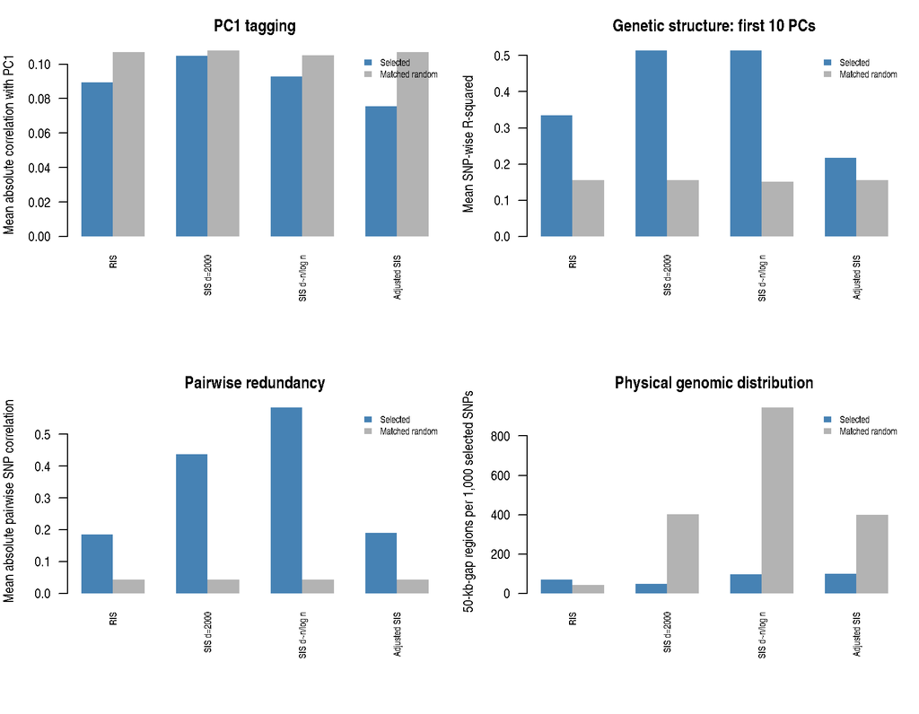

```r
# ------------------------------------------------
# J. Plot selected sets versus matched random references
# ------------------------------------------------

screen_labels <- c(
  SIS_d1 = "SIS d~n/log n",
  SIS_2000 = "SIS d=2000",
  RIS = "RIS",
  SISadj_2000 = "Adjusted SIS"
)

plot_diagnostic <- function(
  selected_col,
  random_col,
  main,
  ylab
) {

  plot_values <- rbind(
    Selected = diag_summary[[selected_col]],
    `Matched random` = diag_summary[[random_col]]
  )

  colnames(plot_values) <- unname(
    screen_labels[diag_summary$set]
  )

  barplot(
    plot_values,
    beside = TRUE,
    col = c("steelblue", "grey70"),
    border = NA,
    las = 2,
    cex.names = 0.75,
    ylab = ylab,
    main = main
  )

  legend(
    "topright",
    legend = rownames(plot_values),
    fill = c("steelblue", "grey70"),
    border = NA,
    bty = "n",
    cex = 0.7
  )
}

par(
  mfrow = c(2, 2),
  mar = c(7, 4, 3, 1)
)

# PC1 association
plot_diagnostic(
  "PC1_mean_abs_r_selected",
  "PC1_mean_abs_r_random",
  "PC1 tagging",
  "Mean absolute correlation with PC1"
)

# Joint structure association
plot_diagnostic(
  "PC1_10_mean_R2_selected",
  "PC1_10_mean_R2_random",
  "Genetic structure: first 10 PCs",
  "Mean SNP-wise R-squared"
)

# LD redundancy
plot_diagnostic(
  "pairwise_abs_r_selected",
  "pairwise_abs_r_random",
  "Pairwise redundancy",
  "Mean absolute pairwise SNP correlation"
)

# Physical genomic distribution
plot_diagnostic(
  "regions_per_1000_selected",
  "regions_per_1000_random",
  "Physical genomic distribution",
  "50-kb-gap regions per 1,000 selected SNPs"
)
```

```r
par(mfrow = c(1, 1))

cat(
  "\nSection 5.2 diagnostics completed:",
  nrow(diag_selected), "selected sets;",
  nrow(diag_random), "random reference sets.\n"
)
```

```
##
## Section 5.2 diagnostics completed: 40 selected sets; 200 random reference sets.
```

The PC1-only comparison does not indicate elevated PC1 association among the selected markers: the mean absolute SNP–PC1 correlation for SIS with 2,000 markers is 0.105, compared with 0.108 for its random reference. In contrast, the average SNP-wise R-squared explained by PC1–PC10 is substantially higher for SIS (0.513) than for random markers (0.155). The corresponding value for SIS with d = n/log(n) is also 0.513, while RIS gives 0.334 and structure-adjusted SIS gives 0.217. Thus, examining PC1 alone would miss much of the association between SIS-selected markers and broader genomic structure.

The selected SIS markers also exhibit substantially higher pairwise genotype correlation than random markers: 0.436 versus 0.044 for SIS with 2,000 markers, and 0.583 versus 0.043 for SIS with d = n/log(n). This is consistent with considerable marker redundancy.

Physical concentration is also pronounced. SIS with 2,000 markers represents approximately 47.8 distinct 50-kb regions per 1,000 selected SNPs, compared with 401.0 for random markers. For SIS with d = n/log(n), the corresponding values are 96.6 and 943.7. In contrast, RIS represents 70.2 regions per 1,000 markers, compared with 42.4 for its random reference. These results indicate substantial differences in the genomic distribution of markers selected by the different procedures.

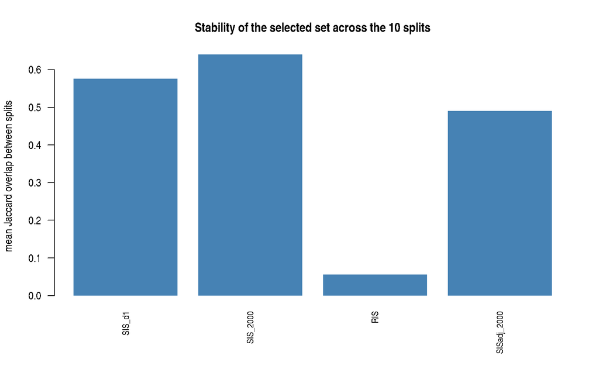

```r
jacc <- function(a, b) length(intersect(a, b)) / length(union(a, b))
stab <- sapply(names(sel_sets[[1]]), function(m)
  mean(combn(length(sel_sets), 2, function(ij) jacc(sel_sets[[ij[1]]][[m]], sel_sets[[ij[2]]][[m]]))))
barplot(stab, col = "steelblue", border = NA, las = 2, cex.names = 0.8, ylab = "mean Jaccard overlap between splits",
        main = "Stability of the selected set across the 10 splits")
```

```r
knitr::kable(data.frame(Screen = names(stab), Mean_Jaccard = round(stab, 3)), row.names = FALSE,
             caption = "1 = identical sets on every split; each pair of splits shares about 64% of its training accessions")
```

1 = identical sets on every split; each pair of splits shares about 64% of its training accessions

| Screen | Mean_Jaccard |
| --- | --- |
| SIS_d1 | 0.576 |
| SIS_2000 | 0.641 |
| RIS | 0.056 |
| SISadj_2000 | 0.491 |

SIS with 2,000 markers has the highest split-to-split Jaccard overlap (0.641), followed by SIS with d = n/log(n) (0.576) and structure-adjusted SIS (0.491). RIS has substantially lower overlap (0.056), consistent with its randomized selection mechanism. These values describe stability across the ten experimental splits, not independent-sample reproducibility: the training sets overlap substantially, sharing approximately 64% of their accessions on average.

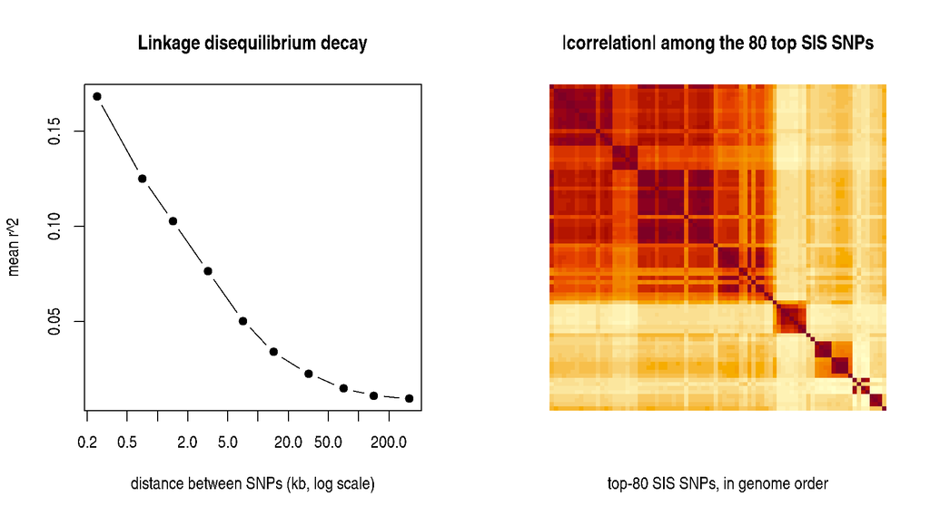

```r
# LD decay: mean r^2 against physical distance, from windows on random chromosomes at three SNP strides
set.seed(77)
ld_pairs <- do.call(rbind, lapply(c(1, 10, 50), function(stride) do.call(rbind, lapply(1:15, function(i) {
  ch <- sample(1:5, 1); idx_ch <- which(chr_int == ch)
  st <- sample(seq_len(length(idx_ch) - 400 * stride), 1); idx <- idx_ch[st + stride * (0:399)]
  r2 <- suppressWarnings(cor(G2[, idx]))^2; dd <- abs(outer(pos_bp[idx], pos_bp[idx], "-"))
  ut <- upper.tri(r2); keep <- ut & !is.na(r2)
  data.frame(dist = dd[keep], r2 = r2[keep])
}))))
brk <- c(0, 500, 1e3, 2e3, 5e3, 1e4, 2e4, 5e4, 1e5, 2e5, 5e5)
ld_pairs$bin <- cut(ld_pairs$dist, brk, include.lowest = TRUE)
ld_curve <- aggregate(r2 ~ bin, data = ld_pairs, FUN = mean)
mids <- sqrt(brk[-length(brk)] * pmax(brk[-1], 1)); mids[1] <- 250; names(mids) <- levels(ld_pairs$bin)
ld_curve$mid <- mids[as.character(ld_curve$bin)]
par(mfrow = c(1, 2))
plot(ld_curve$mid / 1000, ld_curve$r2, type = "b", pch = 19, log = "x", xlab = "distance between SNPs (kb, log scale)",
     ylab = "mean r^2", main = "Linkage disequilibrium decay")
sel_h <- sort(sel_sets[[1]]$SIS_2000[1:80]); o <- order(chr_int[sel_h], pos_bp[sel_h]); sel_h <- sel_h[o]
cm <- abs(suppressWarnings(cor(G2[, sel_h]))); cm[is.na(cm)] <- 0
image(1:80, 1:80, cm[, 80:1], col = hcl.colors(30, "YlOrRd", rev = TRUE), xlab = "top-80 SIS SNPs, in genome order", ylab = "",
      axes = FALSE, main = "|correlation| among the 80 top SIS SNPs")
```

```r
par(mfrow = c(1, 1))
```

The LD-decay curve summarizes mean pairwise r-squared across sampled chromosome windows as a function of physical distance. The correlation heatmap displays pairwise absolute genotype correlations among the 80 SIS markers shown from the first split, ordered by genomic position. These plots provide exploratory descriptions of local and genome-wide correlation patterns. The 50-kb positional regions reported above are a separate heuristic and should not be interpreted as inferred LD blocks.

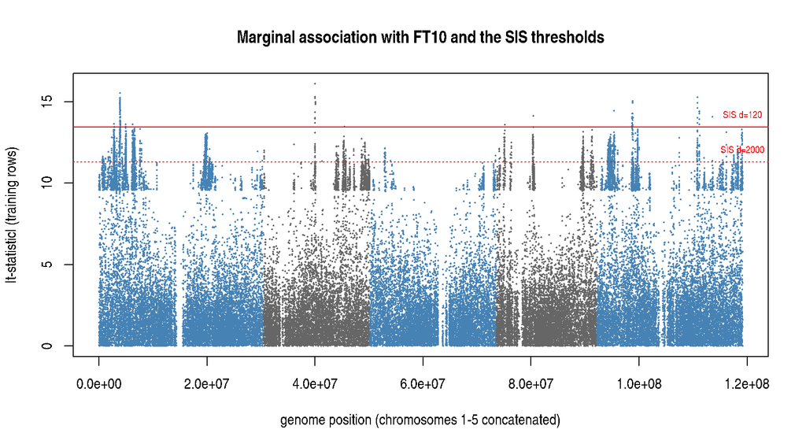

```r
# marginal association of every SNP with FT10 on the training rows of split 1; known loci marked approximately
sp1 <- make_split(1); t1 <- screen_scores(sp1$tr, y_all[sp1$tr]); r1 <- abs(t1)
ok <- !is.na(chr_int) & chr_int %in% 1:5
chr_len <- tapply(pos_bp[ok], chr_int[ok], max)
off <- c(0, cumsum(as.numeric(chr_len))[-length(chr_len)]); names(off) <- names(chr_len)
xcum <- pos_bp + off[as.character(chr_int)]
show <- ok & (r1 > quantile(r1[ok], 0.995) | runif(p) < 0.03)
d1 <- floor(length(sp1$tr) / log(length(sp1$tr)))
thr1 <- sort(r1, decreasing = TRUE)[d1]; thr2 <- sort(r1, decreasing = TRUE)[2000]
plot(xcum[show], r1[show], pch = 16, cex = 0.3, col = c("grey40", "steelblue")[chr_int[show] %% 2 + 1],
     xlab = "genome position (chromosomes 1-5 concatenated)", ylab = "|t-statistic| (training rows)",
     main = "Marginal association with FT10 and the SIS thresholds")
abline(h = c(thr1, thr2), lty = c(1, 3), col = "red")
text(max(xcum[ok]), c(thr1, thr2), c("SIS d=120", "SIS d=2000"), pos = 3, col = "red", cex = 0.7)
```

```r
top15 <- order(r1, decreasing = TRUE)[1:15]
knitr::kable(
  data.frame(
    chr = chr_int[top15],
    pos = pos_bp[top15],
    abs_t = round(r1[top15], 2)
  ),
  row.names = FALSE,
  caption = "Top 15 SNPs by absolute marginal t-statistic in the training data of split 1"
)
```

Top 15 SNPs by absolute marginal t-statistic in the training data of split 1

| chr | pos | abs_t |
| --- | --- | --- |
| 2 | 9581436 | 16.10 |
| 1 | 3905614 | 15.55 |
| 2 | 9589040 | 15.32 |
| 5 | 18590247 | 15.28 |
| 1 | 3902231 | 15.25 |
| 2 | 9590291 | 15.24 |
| 1 | 3903103 | 15.22 |
| 1 | 3874904 | 15.15 |
| 1 | 3874948 | 15.07 |
| 1 | 3876064 | 15.04 |
| 5 | 6628378 | 15.04 |
| 5 | 6628375 | 15.00 |
| 1 | 3875742 | 15.00 |
| 2 | 9604507 | 15.00 |
| 1 | 3876141 | 14.99 |

## 5.3 Semi-synthetic simulation: does screening recover the truth, and what do LD and ancestry do to it?

On real data the causal SNPs are unknown. This simulation keeps the **real genotypes** (so the real LD and ancestry structure are present) and plants a known signal:

$$y = \underbrace{\textstyle\sum_{j\in
S}\beta_j \tilde x_j}_{\text{genetic, variance }h^2_g} +
\underbrace{\gamma\,\tilde u_1}_{\text{ancestry, variance }h^2_a} +
\varepsilon ,\qquad |S|=s,$$

with $\tilde x_j$ standardized causal SNPs and $\tilde u_1$ the first ancestry axis. Scenarios: **A** sparse (s = 20, $h^2_g=0.5$, no ancestry effect); **B** sparse with ancestry confounding (s = 20, $h^2_g=0.3$, $h^2_a=0.4$); **C** polygenic (s = 2000, $h^2_g=0.5$). Each screen is run on a training split and scored by **exact recovery** (fraction of causal SNPs selected), **locus recovery** (fraction of causal SNPs having a selected SNP with $|r|\ge 0.7$, i.e. tagged through LD) and **ancestry tagging** (mean $|r|$ of selected SNPs with axis 1).

```r
SIM_B <- 12
sim_scenarios <- list(A_sparse = list(s = 20, h2g = 0.5, h2a = 0), B_sparse_ancestry = list(s = 20, h2g = 0.3, h2a = 0.4),
                      C_polygenic = list(s = 2000, h2g = 0.5, h2a = 0))
sim_one <- function(scn_name, b) {
  scn <- sim_scenarios[[scn_name]]
  set.seed(5000 + b + 100 * match(scn_name, names(sim_scenarios)))
  causal <- sample(which(maf >= 0.1), scn$s)
  Xc <- scale(G2[, causal]); Xc[is.na(Xc)] <- 0
  g <- as.numeric(Xc %*% rnorm(scn$s)); g <- (g - mean(g)) / sd(g) * sqrt(scn$h2g)
  a <- anc_axis * sqrt(scn$h2a); e <- rnorm(n) * sqrt(max(1 - scn$h2g - scn$h2a, 0.01))
  y <- g + a + e
  sp <- make_split(9000 + b); tr <- sp$tr
  tt <- screen_scores(tr, y[tr]); r <- sign(tt) * sqrt(tt^2 / (tt^2 + length(tr) - 2))
  q_in <- abs(r)^max(0, (1 + log(p / length(tr))) / 2); q_in <- q_in / max(q_in)
  ris <- which(rbinom(p, 1, q_in) == 1)
  tt_adj <- screen_scores(tr, adjust_response(tr, y[tr]))
  d1 <- floor(length(tr) / log(length(tr)))
  sets <- list(SIS_d120 = sis_top(tt, d1), SIS_d2000 = sis_top(tt, 2000), RIS = ris,
               SISadj_d2000 = sis_top(tt_adj, 2000), Random_d2000 = sample(p, 2000))
  do.call(rbind, lapply(names(sets), function(m) {
    sel <- sets[[m]]; Xs <- scale(G2[, sel]); Xs[is.na(Xs)] <- 0
    cc <- abs(crossprod(Xc, Xs)) / (n - 1)
    data.frame(scenario = scn_name, rep = b, method = m, exact = mean(causal %in% sel),
               locus = mean(apply(cc, 1, max) >= 0.7),
               anc_cor = mean(abs(crossprod(anc_axis, Xs)) / (n - 1)), size = length(sel))
  }))
}
sim_file <- file.path("cache", "sim_results.rds")
if (USE_CACHE && file.exists(sim_file)) {
  sim_res <- readRDS(sim_file)
} else {
  sim_res <- do.call(rbind, lapply(names(sim_scenarios), function(sn) do.call(rbind, lapply(seq_len(SIM_B), function(b) {
    cat(sprintf("[simulation] %s replicate %d\n", sn, b)); sim_one(sn, b)}))))
  saveRDS(sim_res, sim_file)
}
```

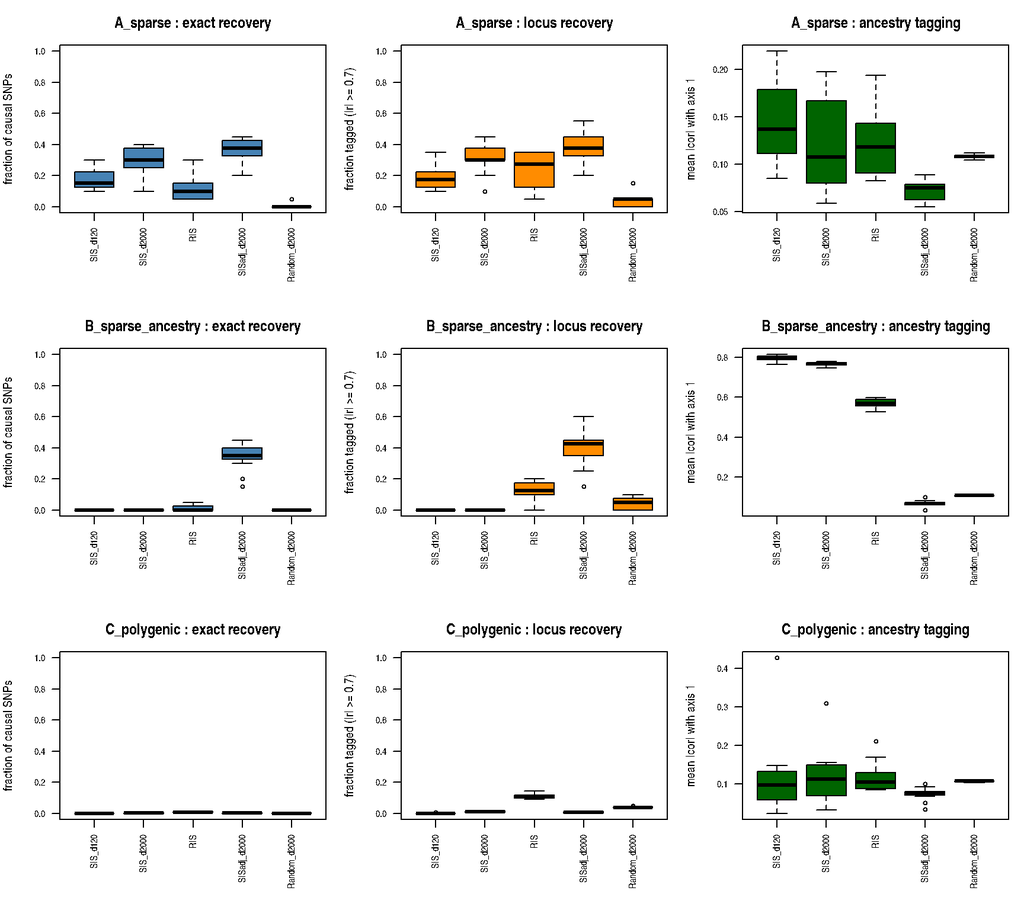

```r
sim_res$method <- factor(sim_res$method, levels = c("SIS_d120", "SIS_d2000", "RIS", "SISadj_d2000", "Random_d2000"))
par(mfrow = c(3, 3), mar = c(6, 4, 3, 1))
for (sn in names(sim_scenarios)) {
  d <- sim_res[sim_res$scenario == sn, ]
  boxplot(exact ~ method, data = d, las = 2, cex.axis = 0.7, ylim = c(0, 1), main = paste(sn, ": exact recovery"), xlab = "", ylab = "fraction of causal SNPs", col = "steelblue")
  boxplot(locus ~ method, data = d, las = 2, cex.axis = 0.7, ylim = c(0, 1), main = paste(sn, ": locus recovery"), xlab = "", ylab = "fraction tagged (|r| >= 0.7)", col = "darkorange")
  boxplot(anc_cor ~ method, data = d, las = 2, cex.axis = 0.7, main = paste(sn, ": ancestry tagging"), xlab = "", ylab = "mean |cor| with axis 1", col = "darkgreen")
}
```

```r
par(mfrow = c(1, 1), mar = c(5, 4, 4, 2))
sim_tab <- aggregate(cbind(exact, locus, anc_cor, size) ~ scenario + method, data = sim_res, FUN = mean)
knitr::kable(sim_tab, digits = 3, row.names = FALSE, caption = sprintf("Semi-synthetic simulation, mean over %d replicates", SIM_B))
```

Semi-synthetic simulation, mean over 12 replicates

| scenario | method | exact | locus | anc_cor | size |
| --- | --- | --- | --- | --- | --- |
| A_sparse | SIS_d120 | 0.179 | 0.188 | 0.143 | 119.00 |
| B_sparse_ancestry | SIS_d120 | 0.000 | 0.000 | 0.796 | 119.00 |
| C_polygenic | SIS_d120 | 0.000 | 0.001 | 0.115 | 119.00 |
| A_sparse | SIS_d2000 | 0.288 | 0.312 | 0.123 | 2000.00 |
| B_sparse_ancestry | SIS_d2000 | 0.000 | 0.000 | 0.766 | 2000.00 |
| C_polygenic | SIS_d2000 | 0.002 | 0.011 | 0.121 | 2000.00 |
| A_sparse | RIS | 0.117 | 0.242 | 0.122 | 2264.75 |
| B_sparse_ancestry | RIS | 0.013 | 0.125 | 0.571 | 20429.92 |
| C_polygenic | RIS | 0.008 | 0.110 | 0.117 | 8522.50 |
| A_sparse | SISadj_d2000 | 0.362 | 0.383 | 0.072 | 2000.00 |
| B_sparse_ancestry | SISadj_d2000 | 0.346 | 0.400 | 0.068 | 2000.00 |
| C_polygenic | SISadj_d2000 | 0.002 | 0.008 | 0.074 | 2000.00 |
| A_sparse | Random_d2000 | 0.008 | 0.038 | 0.108 | 2000.00 |
| B_sparse_ancestry | Random_d2000 | 0.000 | 0.042 | 0.108 | 2000.00 |
| C_polygenic | Random_d2000 | 0.001 | 0.039 | 0.108 | 2000.00 |

```r
g <- function(sn, m, col) sim_tab[[col]][sim_tab$scenario == sn & sim_tab$method == m]
cat(sprintf("- **Exact recovery is low even in the easy sparse scenario** (SIS d=2000: %.2f of causal SNPs), because correlated neighbours compete for the same budget; **locus recovery** is much higher (%.2f), i.e. screening mostly finds the right *regions*, not the right SNPs.\n",
            g("A_sparse", "SIS_d2000", "exact"), g("A_sparse", "SIS_d2000", "locus")))
```

[output not shown]

```r
cat(sprintf("- **Ancestry confounding changes what is selected**: ancestry tagging rises from %.3f (scenario A) to %.3f (scenario B) for SIS d=2000, and falls to %.3f when the response is adjusted for the ancestry axes first (random SNPs: about %.3f). Locus recovery in B: SIS %.2f versus adjusted SIS %.2f.\n",
            g("A_sparse", "SIS_d2000", "anc_cor"), g("B_sparse_ancestry", "SIS_d2000", "anc_cor"),
            g("B_sparse_ancestry", "SISadj_d2000", "anc_cor"), g("B_sparse_ancestry", "Random_d2000", "anc_cor"),
            g("B_sparse_ancestry", "SIS_d2000", "locus"), g("B_sparse_ancestry", "SISadj_d2000", "locus")))
```

- **Ancestry confounding changes what is selected**: ancestry tagging rises from 0.123 (scenario A) to 0.766 (scenario B) for SIS d=2000, and falls to 0.068 when the response is adjusted for the ancestry axes first (random SNPs: about 0.108). Locus recovery in B: SIS 0.00 versus adjusted SIS 0.40.

```r
cat(sprintf("- **Randomized screening (RIS) keeps a large set** (about %.0f SNPs) and recovers loci about as well as hard SIS at that size, while SIS with d = n/log n (%d SNPs) misses many loci: the budget d matters more than the soft-versus-hard rule.\n",
            g("A_sparse", "RIS", "size"), 120L))
```

[output not shown]

```r
cat(sprintf("- **Polygenic truth (scenario C)**: no screen recovers more than %.2f of the 2,000 causal loci, which is why dense models beat screened ones for polygenic traits.\n",
            max(sim_tab$locus[sim_tab$scenario == "C_polygenic" & sim_tab$method != "Random_d2000"])))
```

- **Polygenic truth (scenario C)**: no screen recovers more than 0.11 of the 2,000 causal loci, which is why dense models beat screened ones for polygenic traits.

```r
best <- tab_sis$Method[which.min(tab_sis$Mean_MSPE)]

cat(sprintf("- **On FT10, SIS plus penalized regression** reaches mean MSPE between %.1f and %.1f depending on the recipe (best: `%s`), against %.1f for aggregated TARP and %.1f for full-SNP GBLUP.\n",
            min(tab_sis$Mean_MSPE), max(tab_sis$Mean_MSPE), best, mean(si$RP_agg), mean(sis_res$GBLUP)))
```

- **On FT10, SIS plus penalized regression** reaches mean MSPE between 113.0 and 169.0 depending on the recipe (best: `RIS_ridge`), against 117.5 for aggregated TARP and 107.2 for full-SNP GBLUP.

```r
cat(sprintf("- **A hard d = n/log n cut-off is too small here**: SIS d=%d + lasso scores %.1f, versus %.1f for d = 2000 (both with lasso).\n",
            sis_res$d1[1], mean(sis_res$SIS_d1_lasso), mean(sis_res$SIS_2000_lasso)))
```

- **A hard d = n/log n cut-off is too small here**: SIS d=119 + lasso scores 169.0, versus 137.5 for d = 2000 (both with lasso).

```r
sis2_diag <- diag_summary[
  diag_summary$set == "SIS_2000",
  ,
  drop = FALSE
]

adj_diag <- diag_summary[
  diag_summary$set == "SISadj_2000",
  ,
  drop = FALSE
]

# 1. Genomic structure: PC1 versus PC1-PC10
cat(sprintf(
  "- **PC1 alone does not show enrichment:** the mean absolute SNP-PC1 correlation for SIS with 2,000 markers is %.3f, compared with %.3f for random markers. However, the average SNP-wise R-squared explained by PC1-PC10 is %.3f, compared with %.3f for random markers.\n",
  sis2_diag$PC1_mean_abs_r_selected,
  sis2_diag$PC1_mean_abs_r_random,
  sis2_diag$PC1_10_mean_R2_selected,
  sis2_diag$PC1_10_mean_R2_random
))
```

- **PC1 alone does not show enrichment:** the mean absolute SNP-PC1 correlation for SIS with 2,000 markers is 0.105, compared with 0.108 for random markers. However, the average SNP-wise R-squared explained by PC1-PC10 is 0.513, compared with 0.155 for random markers.

```r
# 2. Marker redundancy and physical concentration
cat(sprintf(
  "- **SIS-selected markers exhibit substantial redundancy and physical concentration:** their mean pairwise absolute genotype correlation is %.3f versus %.3f for random markers, while their number of 50-kb regions per 1,000 SNPs is %.1f versus %.1f for random markers.\n",
  sis2_diag$pairwise_abs_r_selected,
  sis2_diag$pairwise_abs_r_random,
  sis2_diag$regions_per_1000_selected,
  sis2_diag$regions_per_1000_random
))
```

- **SIS-selected markers exhibit substantial redundancy and physical concentration:** their mean pairwise absolute genotype correlation is 0.436 versus 0.044 for random markers, while their number of 50-kb regions per 1,000 SNPs is 47.8 versus 401.0 for random markers.

```r
# 3. Structure-adjusted SIS comparison
cat(sprintf(
  "- **Structure-adjusted SIS reduces association with broader genomic structure:** its average SNP-wise R-squared explained by PC1-PC10 is %.3f, compared with %.3f for ordinary SIS with 2,000 markers and %.3f for random markers. The association is reduced, but not eliminated relative to the random reference.\n",
  adj_diag$PC1_10_mean_R2_selected,
  sis2_diag$PC1_10_mean_R2_selected,
  adj_diag$PC1_10_mean_R2_random
))
```

- **Structure-adjusted SIS reduces association with broader genomic structure:** its average SNP-wise R-squared explained by PC1-PC10 is 0.217, compared with 0.513 for ordinary SIS with 2,000 markers and 0.155 for random markers. The association is reduced, but not eliminated relative to the random reference.

```r
# Run the supplementary SIS stability and redundancy analysis.
# Requires G2, y_all, map, N_CORES and screen_scores()
# to have been created in the preceding sections.

if (!file.exists("add_sis_region_stability.R")) {
  stop("Place add_sis_region_stability.R in the project root folder.")
}

source("add_sis_region_stability.R")
```

```
## SIS stability: subsample 1/10 complete; selected 2000 SNPs.
## SIS stability: subsample 2/10 complete; selected 2000 SNPs.
## SIS stability: subsample 3/10 complete; selected 2000 SNPs.
## SIS stability: subsample 4/10 complete; selected 2000 SNPs.
## SIS stability: subsample 5/10 complete; selected 2000 SNPs.
## SIS stability: subsample 6/10 complete; selected 2000 SNPs.
## SIS stability: subsample 7/10 complete; selected 2000 SNPs.
## SIS stability: subsample 8/10 complete; selected 2000 SNPs.
## SIS stability: subsample 9/10 complete; selected 2000 SNPs.
## SIS stability: subsample 10/10 complete; selected 2000 SNPs.
```

```
##
## SIS STABILITY SUMMARY
##      resolution mean_pairwise_jaccard median_pairwise_jaccard  B top_d
##  Individual SNP             0.5970610               0.6116035 10  2000
##   250-kb window             0.6870731               0.6929825 10  2000
##  subsample_n outer_training_n
##          641              802
##          641              802
##
## Correlation-pruning summary (training genotypes only):
## Top SIS candidates: 2000 | retained after |r| < 0.9 : 535
##
## Top recurrent genomic windows:
##  chromosome window_id window_start window_end region_key n_runs_selected
##           1         6      1500001    1750000        1_6              10
##           1         9      2250001    2500000        1_9              10
##           1        10      2500001    2750000       1_10              10
##           1        11      2750001    3000000       1_11              10
##           1        13      3250001    3500000       1_13              10
##           1        14      3500001    3750000       1_14              10
##           1        15      3750001    4000000       1_15              10
##           1        16      4000001    4250000       1_16              10
##           1        19      4750001    5000000       1_19              10
##           1        24      6000001    6250000       1_24              10
##           1        25      6250001    6500000       1_25              10
##           1        26      6500001    6750000       1_26              10
##           1        30      7500001    7750000       1_30              10
##           1        31      7750001    8000000       1_31              10
##           1        78     19500001   19750000       1_78              10
##  selection_frequency
##                    1
##                    1
##                    1
##                    1
##                    1
##                    1
##                    1
##                    1
##                    1
##                    1
##                    1
##                    1
##                    1
##                    1
##                    1
##
## Outputs saved in: /home/abck/arabidopsis_project/output/sis_region_stability
```

# 6. Does screening add anything to a dense kernel? Targeted GBLUP

Screening is good at finding large-effect SNPs, which a dense ridge dilutes. **Targeted GBLUP** keeps the dense kernel and adds TARP’s own screened set as a second kernel, $K = K_{full} + w\,K_{screened}$: screened SNPs receive a prior-variance boost of about $1 + w\,p/p_{screened}$. $w=0$ is GBLUP; large $w$ approaches the screened-only ridge. $(w,\lambda)$ are chosen by nested CV with re-screening inside each fold.

```r
run_rep_e3 <- function(seed_i) {
  sp <- make_split(seed_i); tr <- sp$tr; te <- sp$te
  y_tr <- y_all[tr]; y_te <- y_all[te]; y_mean <- mean(y_tr)
  sc <- screen_set(tr, y_tr); Ks_all <- screened_gram(sc$inc)
  set.seed(seed_i * 1000 + 7)
  fold <- sample(rep(seq_len(K_IN), length.out = length(tr)))
  cv <- array(0, c(K_IN, length(W_GRID), length(LAM_GRID)))
  for (f in seq_len(K_IN)) {
    in_tr <- tr[fold != f]; in_va <- tr[fold == f]; y_in <- y_all[in_tr]; ym <- mean(y_in)
    Ks_f <- screened_gram(screen_set(in_tr, y_in)$inc)                           # re-screen inside the fold
    for (iw in seq_along(W_GRID)) {
      w <- W_GRID[iw]
      cv[f, iw, ] <- mse_curve(kernel_curve(Kfull[in_tr, in_tr] + w * Ks_f[in_tr, in_tr],
                                             Kfull[in_va, in_tr] + w * Ks_f[in_va, in_tr], y_in - ym, LAM_GRID),
                               y_all[in_va] - ym)
    }
  }
  cvm <- apply(cv, c(2, 3), mean); jl_w <- apply(cvm, 1, which.min)
  best <- arrayInd(which.min(cvm), dim(cvm)); iw_star <- best[1, 1]; il_star <- best[1, 2]
  te_m <- t(vapply(seq_along(W_GRID), function(iw) {
    w <- W_GRID[iw]
    mse_curve(kernel_curve(Kfull[tr, tr] + w * Ks_all[tr, tr], Kfull[te, tr] + w * Ks_all[te, tr], y_tr - y_mean, LAM_GRID),
              y_te - y_mean)
  }, numeric(length(LAM_GRID))))
  out <- data.frame(seed = seed_i, n_screened = length(sc$inc), TwoK_honest = te_m[iw_star, il_star],
                    GBLUP_nested = te_m[1, jl_w[1]], TwoK_oracle = min(te_m), w_sel = W_GRID[iw_star],
                    lam_sel = LAM_GRID[il_star], cv_min = min(cvm))
  for (iw in seq_along(W_GRID)) out[[paste0("T_w", W_GRID[iw])]] <- te_m[iw, jl_w[iw]]
  out
}
e3 <- run_seeds("e3", run_rep_e3, legacy = "exp3_results.rds")
```

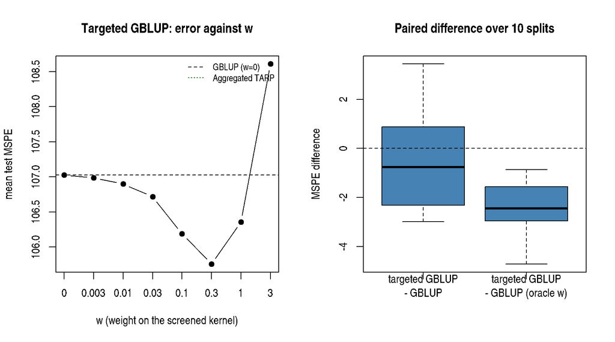

```r
wcols <- paste0("T_w", W_GRID)
mu_w <- sapply(wcols, function(cn) mean(e3[[cn]])); dmat <- sapply(wcols, function(cn) e3[[cn]] - e3$T_w0)
par(mfrow = c(1, 2))
plot(seq_along(W_GRID), mu_w, type = "b", pch = 19, xaxt = "n", xlab = "w (weight on the screened kernel)", ylab = "mean test MSPE",
     main = "Targeted GBLUP: error against w")
axis(1, at = seq_along(W_GRID), labels = W_GRID)
abline(h=mean(e3$GBLUP_nested),lty=2)
abline(h=mean(si$RP_agg),lty=3,col="darkgreen")
legend("topright",c("GBLUP (w=0)","Aggregated TARP"),
       lty=c(2,3),col=c("black","darkgreen"),bty="n",cex=0.8)
boxplot(list("targeted GBLUP\n- GBLUP" = e3$TwoK_honest - e3$GBLUP_nested, "targeted GBLUP\n- GBLUP (oracle w)" = e3$TwoK_oracle - e3$GBLUP_nested),
        ylab = "MSPE difference", col = "steelblue", main = "Paired difference over 10 splits"); abline(h = 0, lty = 2)
```

```r
par(mfrow = c(1, 1))
d3 <- e3$TwoK_honest - e3$GBLUP_nested
cat(sprintf("Targeted GBLUP minus GBLUP (both nested-tuned): %.2f (SE %.2f), better in %d of %d splits; w chosen: %s. Peeking at the test set (oracle) would gain %.1f.\n",
            mean(d3), sem(d3), sum(d3 < 0), nrow(e3), paste(names(table(e3$w_sel)), table(e3$w_sel), sep = "x", collapse = ", "),
            mean(e3$GBLUP_nested - e3$TwoK_oracle)))
```

```
## Targeted GBLUP minus GBLUP (both nested-tuned): -0.57 (SE 0.64), better in 7 of 10 splits; w chosen: 0.1x1, 0.3x4, 1x5. Peeking at the test set (oracle) would gain 2.5.
```

# 7 Other clustering methods specific to categorical data:

## 7.1 Latent class analysis (LCA) of the genotypes, fitted by EM

A latent class model for binary genotypes (a Bernoulli mixture) is fitted by the EM algorithm on a thinned, evenly spaced panel of 800 SNPs with minor allele frequency at least 0.1: each accession gets soft class memberships $R$ ($n\times K$), with class-specific allele probabilities $\theta_{kj}$ and mixing weights $\pi_k$. No response is used. Neighbouring SNPs are not independent given the class, so BIC favors many classes; the classes are flexible ancestry features, not a taxonomy.

```r
lca_em <- function(B, K, n_init = 10, iters = 300, tol = 1e-7) {
  n_ <- nrow(B); best <- NULL
  for (s in seq_len(n_init)) {
    R <- matrix(runif(n_ * K), n_, K); R <- R / rowSums(R); ll_old <- -Inf
    for (it in seq_len(iters)) {
      pi_k <- pmax(colMeans(R), 1e-8)                                              # M-step
      theta <- sweep(t(R) %*% B + 0.5, 1, colSums(R) + 1, "/")
      logp <- B %*% t(log(theta)) + (1 - B) %*% t(log(1 - theta))                  # E-step
      logp <- sweep(logp, 2, log(pi_k), "+")
      m <- apply(logp, 1, max); lse <- m + log(rowSums(exp(logp - m)))
      R <- exp(logp - lse); ll <- sum(lse)
      if (abs(ll - ll_old) < tol * abs(ll)) break
      ll_old <- ll
    }
    if (is.null(best) || ll > best$ll) best <- list(R = R, ll = ll)
  }
  best
}
set.seed(2025)
Xp <- G2[, round(seq(1, p, length.out = 30000))]; f_l <- colMeans(Xp) / 2
Xp <- Xp[, f_l > 0.1 & f_l < 0.9]
B_lca <- (Xp[, round(seq(1, ncol(Xp), length.out = min(800, ncol(Xp))))] >= 1) * 1; rm(Xp)
K_LCA_SET <- c(2:8, 10, 12, 16, 20, 24)
lca_file <- file.path("cache", "lca_fits.rds")
if (USE_CACHE && file.exists(lca_file)) {
  fits <- readRDS(lca_file)
} else {
  fits <- lapply(K_LCA_SET, function(k) lca_em(B_lca, k)); names(fits) <- K_LCA_SET; saveRDS(fits, lca_file)
}
bic <- sapply(names(fits), function(k) { k <- as.integer(k); -2 * fits[[as.character(k)]]$ll + ((k - 1) + k * ncol(B_lca)) * log(n) })
Rmem8 <- fits[["8"]]$R; hard8 <- max.col(Rmem8)
cat("Class sizes at K = 8:", paste(table(hard8), collapse = " / "), "\nMean FT10 by class:", paste(round(tapply(y_all, hard8, mean), 1), collapse = " / "), "\n")
```

```
## Class sizes at K = 8: 183 / 146 / 138 / 163 / 71 / 120 / 63 / 119
## Mean FT10 by class: 98 / 69.8 / 77.5 / 87.4 / 80.6 / 78.9 / 110.5 / 72.4
```

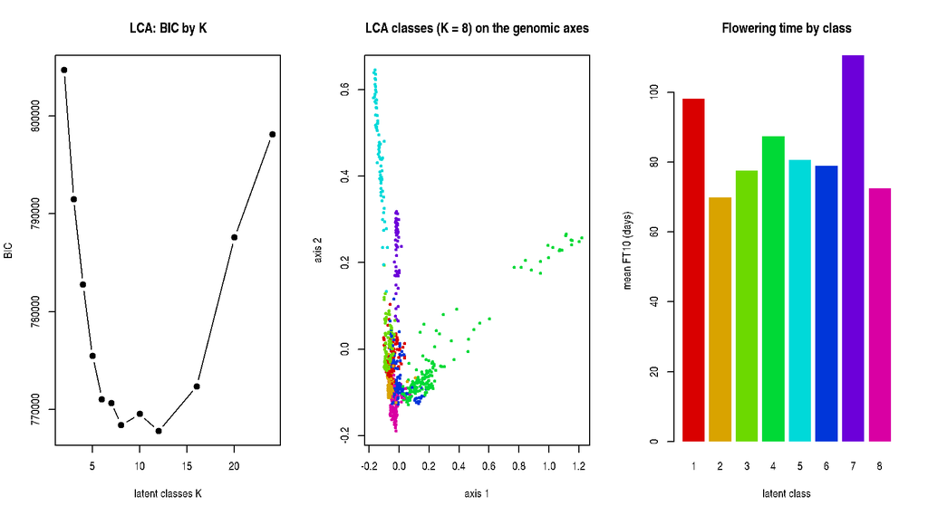

```r
par(mfrow = c(1, 3))
plot(as.integer(names(bic)), bic, type = "b", pch = 19, xlab = "latent classes K", ylab = "BIC", main = "LCA: BIC by K")
pal <- rainbow(8, v = 0.85)
plot(pcs5[, 1], pcs5[, 2], pch = 16, cex = 0.6, col = pal[hard8], xlab = "axis 1", ylab = "axis 2", main = "LCA classes (K = 8) on the genomic axes")
barplot(tapply(y_all, hard8, mean), col = pal, border = NA, xlab = "latent class", ylab = "mean FT10 (days)", main = "Flowering time by class")
```

```r
par(mfrow = c(1, 1))
```

```r
library(dplyr)
library(ggplot2)
library(plotly)

K_values <- 3:8

# --------------------------------------------------
# 1. Calculate class assignments and class summaries
# --------------------------------------------------

class_sizes <- bind_rows(lapply(K_values, function(k) {

  R <- fits[[as.character(k)]]$R

  # Modal posterior class assignment
  assignment <- max.col(R, ties.method = "first")

  stopifnot(length(assignment) == length(y_all))

  df <- data.frame(
    Class = assignment,
    FT10 = y_all
  )

  df %>%
    group_by(Class) %>%
    summarise(
      N = n(),
      Mean_FT10 = mean(FT10, na.rm = TRUE),
      SD_FT10 = sd(FT10, na.rm = TRUE),
      N_FT10 = sum(!is.na(FT10)),
      .groups = "drop"
    ) %>%
    mutate(
      K = paste0("K = ", k),
      Percentage = 100 * N / sum(N),
      Class = factor(
        paste0("Class ", Class),
        levels = paste0("Class ", 1:k)
      ),
      Hover = paste0(
        "<b>", K, " | ", Class, "</b>",
        "<br>Number of accessions: ", N,
        "<br>Percentage: ", round(Percentage, 2), "%",
        "<br>Mean FT10: ", round(Mean_FT10, 3),
        "<br>SD FT10: ", round(SD_FT10, 3),
        "<br>Non-missing FT10: ", N_FT10
      ),
      Bar_Label = paste0(
        "N = ", N,
        "<br>Mean = ", round(Mean_FT10, 1)
      )
    )
}))

# --------------------------------------------------
# 2. Interactive bar plot
# --------------------------------------------------

p_class <- ggplot(
  class_sizes,
  aes(
    x = Class,
    y = N,
    fill = Class,
    text = Hover
  )
) +

  geom_col(width = 0.72, show.legend = FALSE) +

  geom_text(
    aes(label = Bar_Label),
    vjust = -0.35,
    size = 3,
    lineheight = 1.1
  ) +

  facet_wrap(~K, ncol = 3, scales = "free_x") +

  scale_fill_brewer(palette = "Set2") +

  scale_y_continuous(
    expand = expansion(mult = c(0, 0.22))
  ) +

  labs(
    title = "Latent Class Sizes and Phenotypic Profiles",
    subtitle = "Modal posterior assignment across LCA solutions",
    x = "Latent class",
    y = "Number of accessions"
  ) +

  theme_minimal(base_size = 12) +

  theme(
    plot.title = element_text(face = "bold", size = 15),
    strip.text = element_text(face = "bold", size = 12),
    axis.text.x = element_text(angle = 35, hjust = 1),
    panel.grid.major.x = element_blank(),
    panel.grid.minor = element_blank()
  )

ggplotly(p_class, tooltip = "text") %>%
  layout(
    hoverlabel = list(align = "left"),
    margin = list(t = 90)
  )
```

[interactive chart not shown]